# Tugas Pertemuan 1 - Qanita Basimah Kurnia

```r
library(forecast)
library(graphics)
library(TTR)
library(TSA)
library(rio)
library(readxl)
library(ggplot2)
```

## Impor Data

```r
data1 <- read_xlsx("C:\\Users\\62895\\Downloads\\Data Energi 2021 (data kelompok).xlsx")

head(data1)
```

```
## # A tibble: 6 × 4
##   Tanggal    Hari  Periode Beban_Listrik
##   <chr>      <chr>   <dbl>         <dbl>
## 1 2021-01-01 Jum         1        45717.
## 2 2021-01-02 Sab         2        48892.
## 3 2021-01-03 Min         3        50647.
## 4 2021-01-04 Sen         4        61716.
## 5 2021-01-05 Sel         5        63290.
## 6 2021-01-06 Rab         6        60524.
```

## Eksplorasi Data

```r
View(data1)
str(data1)
```

```
## tibble [365 × 4] (S3: tbl_df/tbl/data.frame)
##  $ Tanggal      : chr [1:365] "2021-01-01" "2021-01-02" "2021-01-03" "2021-01-04" ...
##  $ Hari         : chr [1:365] "Jum" "Sab" "Min" "Sen" ...
##  $ Periode      : num [1:365] 1 2 3 4 5 6 7 8 9 10 ...
##  $ Beban_Listrik: num [1:365] 45717 48892 50647 61716 63290 ...
```

```r
dim(data1)
```

```
## [1] 365   4
```

```r
data1.ts <- ts(data1$Beban_Listrik)
```

Menampilkan ringkasan data

```r
summary(data1.ts)
```

```
##    Min. 1st Qu.  Median    Mean 3rd Qu.    Max.
##   44072   54005   57884   57603   62540   70036
```

Membuat plot data deret waktu

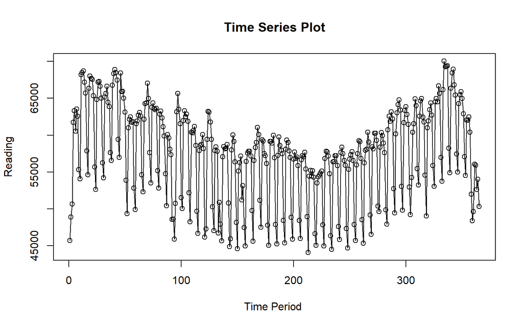

```r
ts.plot(data1.ts, xlab="Time Period ", ylab="Reading",
        main = "Time Series Plot")
points(data1.ts)
```

```r
#menyimpan plot
dev.copy(png, "plot_data1.png")
```

```r
dev.off()
```

## Single Moving Average & Double Moving Average

### Pembagian Data

Pembagian data latih dan data uji dilakukan dengan perbandingan 80% data latih dan 20% data uji.

```r
# hitung jumlah data
n <- nrow(data1)

# tentukan batas 80%
n_train <- floor(0.8 * n)
n_test <- n - n_train

# bagi data
training_ma <- data1[1:n_train, ]
testing_ma  <- data1[(n_train+1):n, ]

# ubah ke time series
train_ma.ts <- ts(training_ma$Beban_Listrik)
test_ma.ts  <- ts(testing_ma$Beban_Listrik)
```

Eksplorasi data dilakukan pada keseluruhan data, data latih serta data uji menggunakan plot data deret waktu.

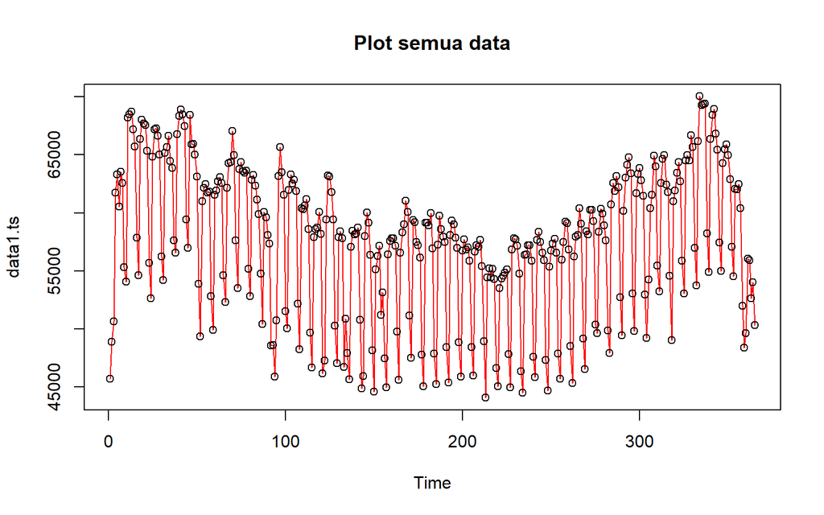

```r
#eksplorasi keseluruhan data
plot(data1.ts, col="red",main="Plot semua data")
points(data1.ts)
```

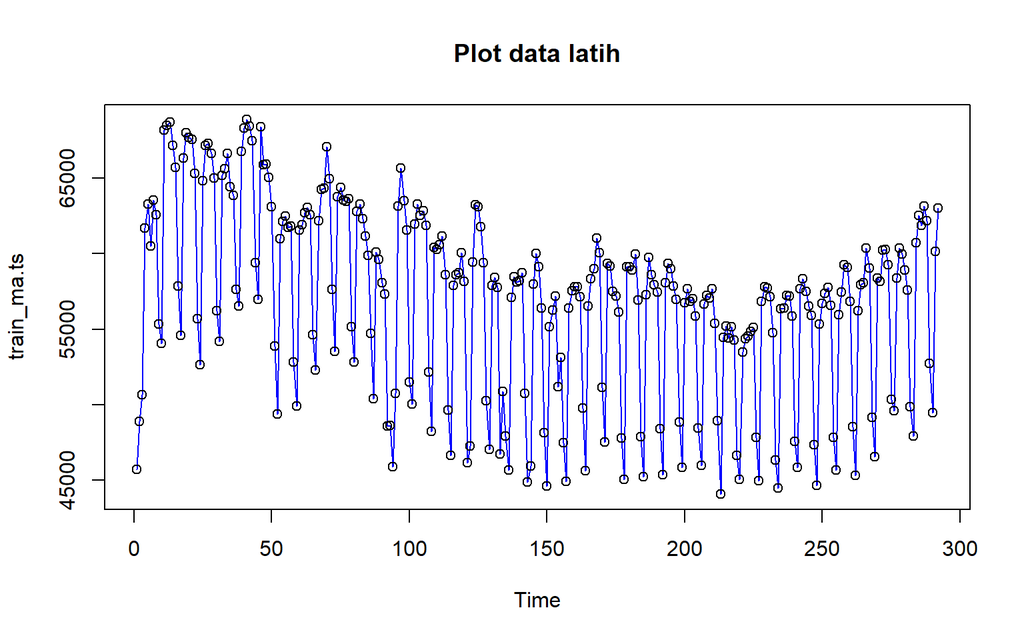

```r
#eksplorasi data latih
plot(train_ma.ts, col="blue",main="Plot data latih")
points(train_ma.ts)
```

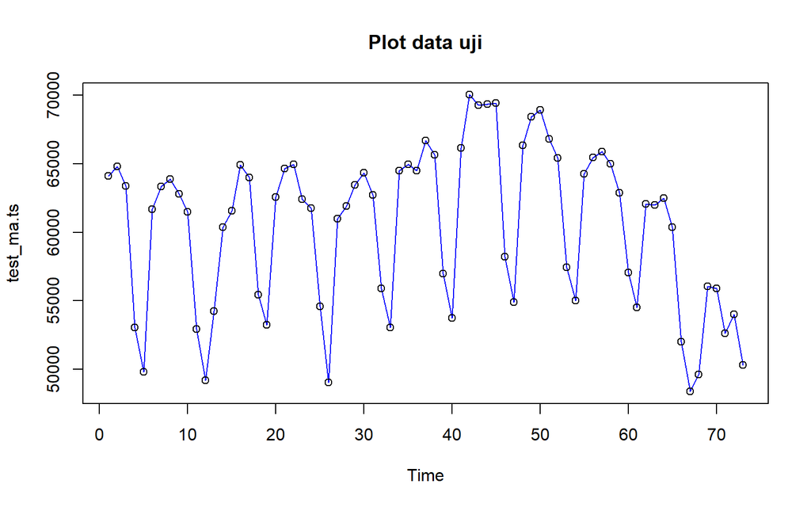

```r
#eksplorasi data uji
plot(test_ma.ts, col="blue",main="Plot data uji")
points(test_ma.ts)
```

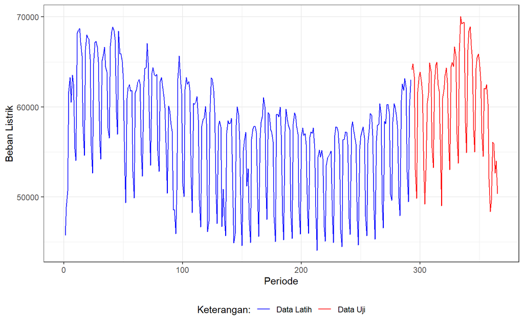

```r
ggplot() +
  geom_line(data = training_ma, aes(x = Periode, y = Beban_Listrik, col = "Data Latih")) +
  geom_line(data = testing_ma, aes(x = Periode, y = Beban_Listrik, col = "Data Uji")) +
  labs(x = "Periode", y = "Beban Listrik", color = "Legend") +
   scale_colour_manual(name="Keterangan:", breaks = c("Data Latih", "Data Uji"),
                      values = c("blue", "red")) +
  theme_bw() + theme(legend.position = "bottom",
                     plot.caption = element_text(hjust=0.5, size=12))
```

### Single Moving Average (SMA)

Pemulusan menggunakan metode SMA dilakukan dengan fungsi `SMA()`. Dalam hal ini akan dilakukan pemulusan dengan parameter `m=7`.

```r
n_values <- c(3, 5, 7, 10, 14, 21)
hasil_mape <- c()

for (n_try in n_values) {
  sma_try <- SMA(train_ma.ts, n = n_try)
  ramal_try <- c(NA, sma_try)

  idx <- (n_try+1):length(train_ma.ts)
  error <- train_ma.ts - ramal_try[1:length(train_ma.ts)]
  mape <- mean(abs(error[idx] / train_ma.ts[idx]) * 100)

  hasil_mape <- c(hasil_mape, mape)
}

data.frame(n = n_values, MAPE = hasil_mape)
```

```
##    n      MAPE
## 1  3 10.467877
## 2  5 10.426106
## 3  7  8.308677
## 4 10  8.899450
## 5 14  8.391069
## 6 21  8.461826
```

```r
m <- 7
```

```r
data.sma<-SMA(train_ma.ts, n=7)
data.sma
```

```
## Time Series:
## Start = 1
## End = 292
## Frequency = 1
##   [1]       NA       NA       NA       NA       NA       NA 56330.88 58738.10
##   [9] 59656.78 60142.49 61066.89 61808.72 62981.70 63501.21 63948.73 64308.49
##  [17] 64387.12 64124.63 64059.31 63910.52 63967.24 63914.23 63604.55 63326.27
##  [25] 63110.64 62988.75 62931.44 62798.69 62752.84 62834.23 63053.68 63102.11
##  [33] 62884.58 62791.94 62479.83 62316.69 62514.00 62850.33 63076.90 63460.74
##  [41] 63779.82 64354.31 64869.66 65124.39 65185.78 65422.39 65073.21 64651.98
##  [49] 64161.66 63537.97 62746.86 61660.46 60597.42 60060.31 59566.55 59096.28
##  [57] 58913.19 58764.30 58840.13 58924.84 58897.35 58929.19 59116.18 59225.30
##  [65] 59482.76 59827.97 59913.63 60247.52 60485.85 61058.88 61396.80 61827.31
##  [73] 61998.60 62225.95 62240.42 62127.73 61610.59 61420.13 61064.92 60967.93
##  [81] 60833.62 60675.43 60496.38 60167.67 59636.10 59576.82 59230.82 58840.19
```

[output cut: 26 more lines]

Data pemulusan pada periode ke-t selanjutnya digunakan sebagai nilai peramalan pada periode ke t+1 sehingga hasil peramalan 1 periode kedepan adalah sebagai berikut.

```r
data.ramal<-c(NA,data.sma)
data.ramal #forecast 1 periode ke depan
```

```
##   [1]       NA       NA       NA       NA       NA       NA       NA 56330.88
##   [9] 58738.10 59656.78 60142.49 61066.89 61808.72 62981.70 63501.21 63948.73
##  [17] 64308.49 64387.12 64124.63 64059.31 63910.52 63967.24 63914.23 63604.55
##  [25] 63326.27 63110.64 62988.75 62931.44 62798.69 62752.84 62834.23 63053.68
##  [33] 63102.11 62884.58 62791.94 62479.83 62316.69 62514.00 62850.33 63076.90
##  [41] 63460.74 63779.82 64354.31 64869.66 65124.39 65185.78 65422.39 65073.21
##  [49] 64651.98 64161.66 63537.97 62746.86 61660.46 60597.42 60060.31 59566.55
##  [57] 59096.28 58913.19 58764.30 58840.13 58924.84 58897.35 58929.19 59116.18
##  [65] 59225.30 59482.76 59827.97 59913.63 60247.52 60485.85 61058.88 61396.80
##  [73] 61827.31 61998.60 62225.95 62240.42 62127.73 61610.59 61420.13 61064.92
##  [81] 60967.93 60833.62 60675.43 60496.38 60167.67 59636.10 59576.82 59230.82
##  [89] 58840.19 58316.41 57709.82 57166.01 55546.53 54670.55 54027.09 52693.82
##  [97] 53199.88 54285.55 55164.98 57020.36 57434.86 58025.49 59624.35 59645.30
## [105] 59197.51 59104.04 59148.35 59243.19 58986.91 58767.93 58341.03 58065.85
## [113] 57826.63 57359.96 57001.04 56774.50 56412.88 56171.37 55905.09 55749.65
```

[output cut: 22 more lines]

Selanjutnya dilakukan peramalan sebanyak 73 priode sesuai dengan jumlah data uji. Pada metode SMA, seluruh hasil peramalan untuk 72 periode ke depan akan memiliki nilai yang sama dengan hasil ramalan satu periode ke depan.

```r
data.gab<-cbind(
  aktual=c(data1.ts),
  pemulusan=c(data.sma,rep(NA,n_test)),
  ramalan=c(data.ramal,rep(data.ramal[length(data.ramal)],n_test - 1)))

data.gab
```

```
##          aktual pemulusan  ramalan
##   [1,] 45716.98        NA       NA
##   [2,] 48891.70        NA       NA
##   [3,] 50646.64        NA       NA
##   [4,] 61715.99        NA       NA
##   [5,] 63290.04        NA       NA
##   [6,] 60523.86        NA       NA
##   [7,] 63530.96  56330.88       NA
##   [8,] 62567.52  58738.10 56330.88
##   [9,] 55322.42  59656.78 58738.10
##  [10,] 54046.64  60142.49 59656.78
##  [11,] 68186.82  61066.89 60142.49
##  [12,] 68482.79  61808.72 61066.89
##  [13,] 68734.76  62981.70 61808.72
##  [14,] 67167.55  63501.21 62981.70
```

[output cut: 351 more lines]

Adapun plot data deret waktu dari hasil peramalan yang dilakukan adalah sebagai berikut.

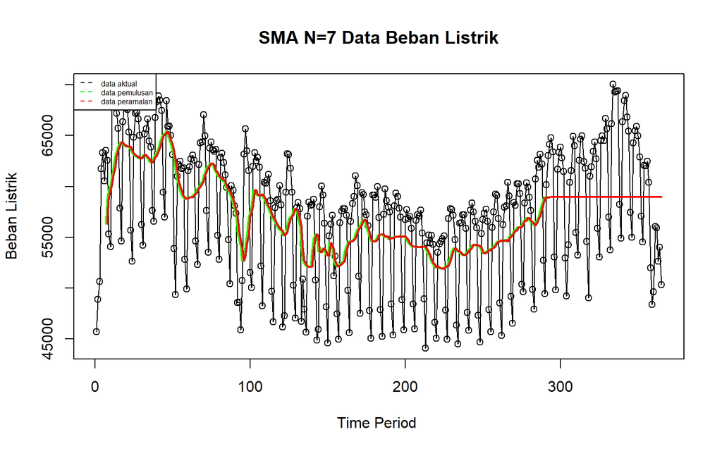

```r
ts.plot(data1.ts, xlab="Time Period ", ylab="Beban Listrik", main= "SMA N=7 Data Beban Listrik")
points(data1.ts)
lines(data.gab[,2],col="green",lwd=2)
lines(data.gab[,3],col="red",lwd=2)
legend("topleft",c("data aktual","data pemulusan","data peramalan"), lty=8, col=c("black","green","red"), cex=0.5)
```

Selanjutnya perhitungan akurasi dilakukan dengan ukuran akurasi *Sum Squares Error* (SSE), *Mean Square Error* (MSE) dan *Mean Absolute Percentage Error* (MAPE). Perhitungan akurasi dilakukan baik pada data latih maupun pada data uji.

```r
#Menghitung nilai keakuratan data latih
error_train.sma = train_ma.ts-data.ramal[1:length(train_ma.ts)]

idx_train <- (m+1):length(train_ma.ts)
SSE_train.sma = sum(error_train.sma[idx_train]^2)
MSE_train.sma = mean(error_train.sma[idx_train]^2)
MAPE_train.sma = mean(abs((error_train.sma[idx_train]/train_ma.ts[idx_train])*100))

akurasi_train.sma <- matrix(c(SSE_train.sma, MSE_train.sma, MAPE_train.sma))
row.names(akurasi_train.sma)<- c("SSE", "MSE", "MAPE")
colnames(akurasi_train.sma) <- c("Akurasi m = 7")
akurasi_train.sma
```

```
##      Akurasi m = 7
## SSE   7.860849e+09
## MSE   2.758193e+07
## MAPE  8.308677e+00
```

Dalam hal ini nilai MAPE data latih pada metode pemulusan SMA sekitar 8%, nilai ini dapat dikategorikan sebagai nilai akurasi yang sangat baik. Selanjutnya dilakukan perhitungan nilai MAPE data uji pada metode pemulusan SMA.

```r
#Menghitung nilai keakuratan data uji
error_test.sma = test_ma.ts - data.gab[(n_train+1):n, 3]

SSE_test.sma = sum(error_test.sma^2)
MSE_test.sma = mean(error_test.sma^2)
MAPE_test.sma = mean(abs((error_test.sma/test_ma.ts*100)))

akurasi_test.sma <- matrix(c(SSE_test.sma, MSE_test.sma, MAPE_test.sma))
row.names(akurasi_test.sma)<- c("SSE", "MSE", "MAPE")
colnames(akurasi_test.sma) <- c("Akurasi m = 7")
akurasi_test.sma
```

```
##      Akurasi m = 7
## SSE   2.628000e+09
## MSE   3.600001e+07
## MAPE  9.060492e+00
```

Perhitungan akurasi menggunakan data latih menghasilkan nilai MAPE yang kurang dari 10% sehingga nilai akurasi ini dapat dikategorikan sebagai sangat baik.

### Double Moving Average (DMA)

Metode pemulusan Double Moving Average (DMA) pada dasarnya mirip dengan SMA. Namun demikian, metode ini lebih cocok digunakan untuk pola data trend. Proses pemulusan dengan rata rata dalam metode ini dilakukan sebanyak 2 kali.

```r
dma <- SMA(data.sma, n = m)
At <- 2*data.sma - dma
Bt <- 2/(m-1)*(data.sma - dma)
data.dma <- At + Bt
data.ramal2 <- c(NA, data.dma)

t = 1:n_test
f = c()

for (i in t) {
  f[i] = At[length(At)] + Bt[length(Bt)]*(i)
}

data.gab2 <- cbind(aktual = c(data1.ts),
                   pemulusan1 = c(data.sma, rep(NA, n_test)),
                   pemulusan2 = c(dma, rep(NA, n_test)),
                   At = c(At, rep(NA, n_test)),
                   Bt = c(Bt, rep(NA, n_test)),
                   ramalan = c(data.ramal2, f[-1]))
data.gab2
```

```
##          aktual pemulusan1 pemulusan2       At           Bt  ramalan
##   [1,] 45716.98         NA         NA       NA           NA       NA
##   [2,] 48891.70         NA         NA       NA           NA       NA
##   [3,] 50646.64         NA         NA       NA           NA       NA
##   [4,] 61715.99         NA         NA       NA           NA       NA
##   [5,] 63290.04         NA         NA       NA           NA       NA
##   [6,] 60523.86         NA         NA       NA           NA       NA
##   [7,] 63530.96   56330.88         NA       NA           NA       NA
##   [8,] 62567.52   58738.10         NA       NA           NA       NA
##   [9,] 55322.42   59656.78         NA       NA           NA       NA
##  [10,] 54046.64   60142.49         NA       NA           NA       NA
##  [11,] 68186.82   61066.89         NA       NA           NA       NA
##  [12,] 68482.79   61808.72         NA       NA           NA       NA
##  [13,] 68734.76   62981.70   60103.65 65859.75   959.350000       NA
##  [14,] 67167.55   63501.21   61127.98 65874.44   791.076531 66819.10
```

[output cut: 351 more lines]

Hasil pemulusan menggunakan metode DMA divisualisasikan sebagai berikut

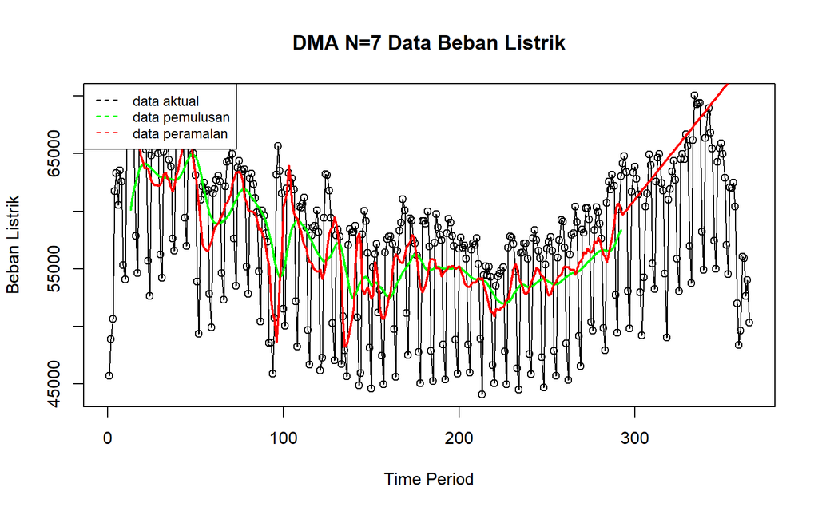

```r
ts.plot(data1.ts, xlab="Time Period", ylab="Beban Listrik", main= "DMA N=7 Data Beban Listrik")
points(data1.ts)
lines(data.gab2[,3],col="green",lwd=2)
lines(data.gab2[,6],col="red",lwd=2)
legend("topleft",c("data aktual","data pemulusan","data peramalan"), lty=8, col=c("black","green","red"), cex=0.8)
```

Selanjutnya perhitungan akurasi dilakukan baik pada data latih maupun data uji. Perhitungan akurasi dilakukan dengan ukuran akurasi SSE, MSE dan MAPE.

```r
#Menghitung nilai keakuratan data latih
error_train.dma = train_ma.ts - data.ramal2[1:length(train_ma.ts)]

idx_train_dma <- (2*m):length(train_ma.ts)
SSE_train.dma = sum(error_train.dma[idx_train_dma]^2)
MSE_train.dma = mean(error_train.dma[idx_train_dma]^2)
MAPE_train.dma = mean(abs((error_train.dma[idx_train_dma]/train_ma.ts[idx_train_dma])*100))

akurasi_train.dma <- matrix(c(SSE_train.dma, MSE_train.dma, MAPE_train.dma))
row.names(akurasi_train.dma)<- c("SSE", "MSE", "MAPE")
colnames(akurasi_train.dma) <- c("Akurasi m = 7")
akurasi_train.dma
```

```
##      Akurasi m = 7
## SSE   7.969368e+09
## MSE   2.856404e+07
## MAPE  8.240698e+00
```

Perhitungan akurasi pada data latih menggunakan nilai MAPE menghasilkan nilai MAPE yang kurang dari 10% sehingga dikategorikan sangat baik. Selanjutnya, perhitungan nilai akurasi dilakukan pada data uji.

```r
#Menghitung nilai keakuratan data uji
error_test.dma = test_ma.ts - data.gab2[(n_train+1):n, 6]
SSE_test.dma = sum(error_test.dma^2)
MSE_test.dma = mean(error_test.dma^2)
MAPE_test.dma = mean(abs((error_test.dma/test_ma.ts*100)))

akurasi_test.dma <- matrix(c(SSE_test.dma, MSE_test.dma, MAPE_test.dma))
row.names(akurasi_test.dma)<- c("SSE", "MSE", "MAPE")
colnames(akurasi_test.dma) <- c("Akurasi m = 7")
akurasi_test.dma
```

```
##      Akurasi m = 7
## SSE   6.744796e+09
## MSE   9.239447e+07
## MAPE  1.277150e+01
```

## Single Exponential Smoothing & Double Exponential Smoothing

Metode Exponential Smoothing merupakan metode pemulusan deret waktu dengan memberikan bobot yang menurun secara eksponensial pada data historis, di mana nilai terbaru mendapat bobot lebih besar dibanding nilai yang lebih lama. Metode ini menggunakan satu atau lebih parameter pemulusan yang secara langsung menentukan besar kecilnya bobot setiap pengamatan. Pemilihan parameter yang tepat akan sangat berpengaruh terhadap hasil ramalan. Secara umum, Exponential Smoothing dibedakan menjadi dua jenis, yaitu model tunggal (single) yang digunakan untuk data tanpa tren maupun musiman, serta model ganda (double) yang mampu menangkap adanya tren pada data.

### Pembagian Data

Pembagian data latih dan data uji dilakukan dengan perbandingan 80% data latih dan 20% data uji.

```r
# jumlah baris data
n <- nrow(data1)

# hitung batas 80%
n_train <- floor(0.8 * n)

# bagi data
training <- data1[1:n_train, ]
testing  <- data1[(n_train+1):n, ]

# ubah ke time series
train.ts <- ts(training$Beban_Listrik)
test.ts  <- ts(testing$Beban_Listrik)
```

### Eksplorasi

Eksplorasi dilakukan dengan membuat plot data deret waktu untuk keseluruhan data, data latih, dan data uji.

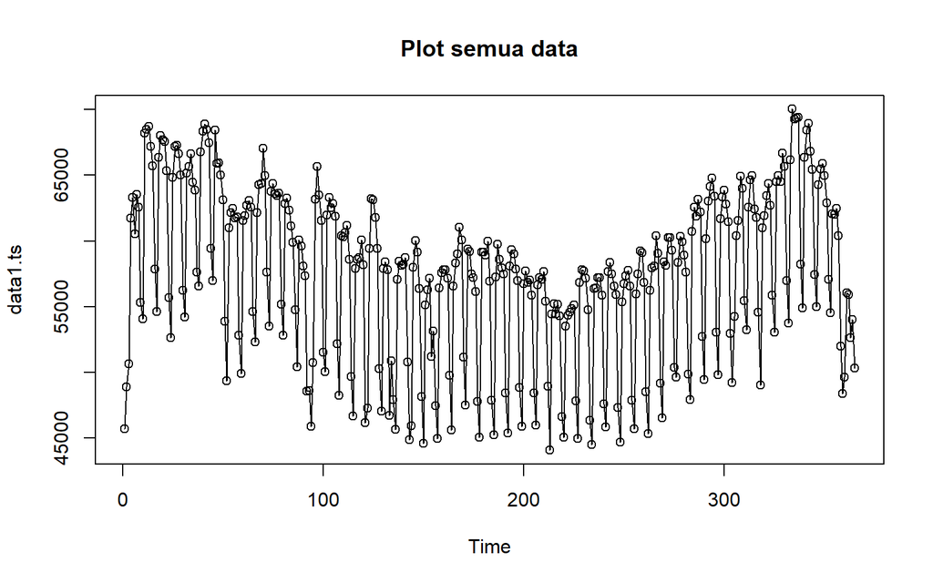

```r
#eksplorasi data
plot(data1.ts, col="black",main="Plot semua data")
points(data1.ts)
```

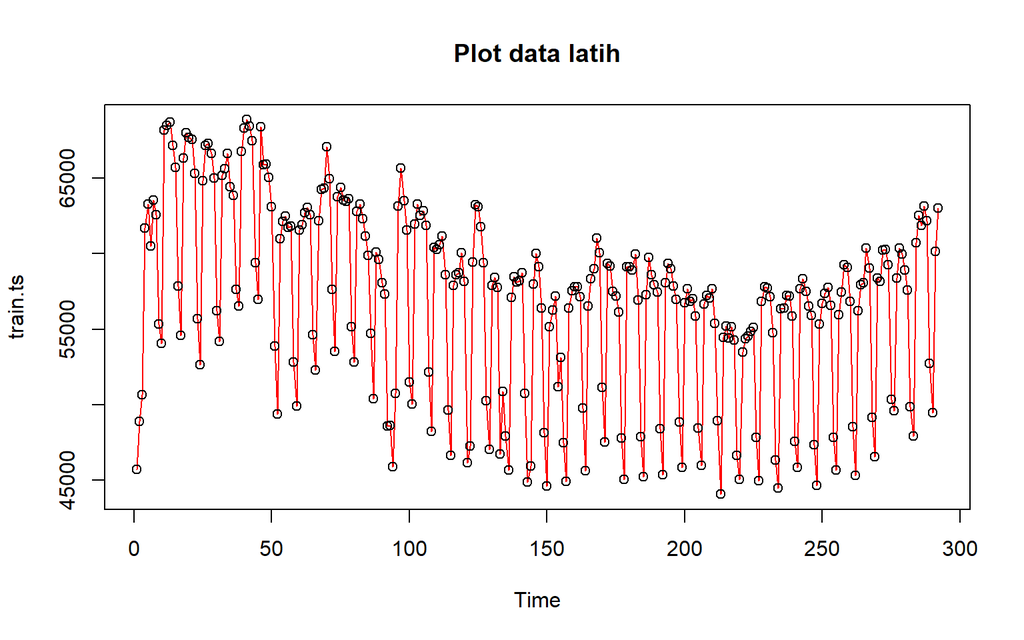

```r
plot(train.ts, col="red",main="Plot data latih")
points(train.ts)
```

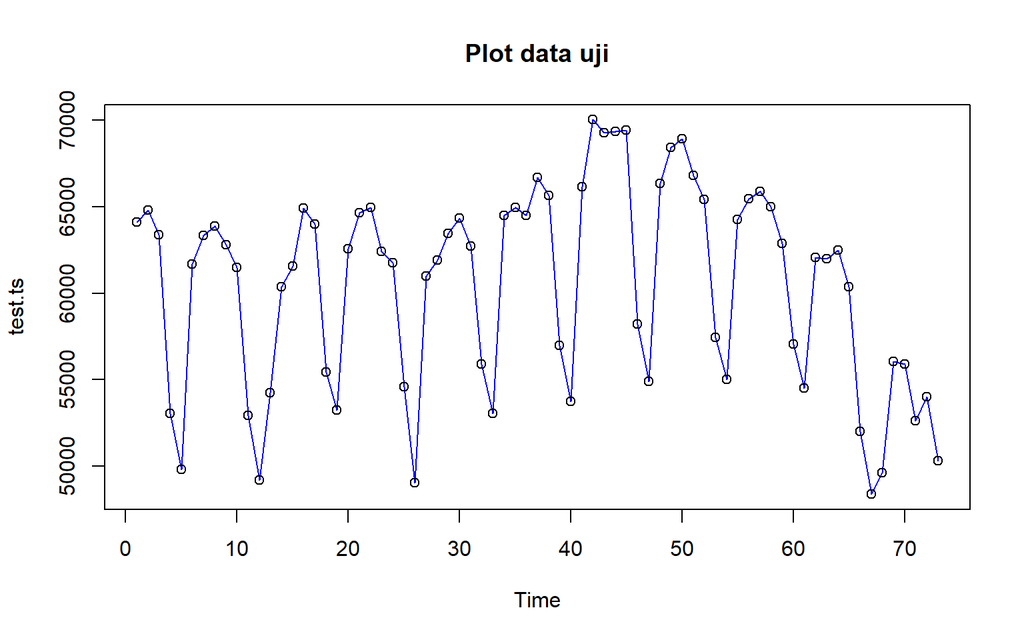

```r
plot(test.ts, col="blue",main="Plot data uji")
points(test.ts)
```

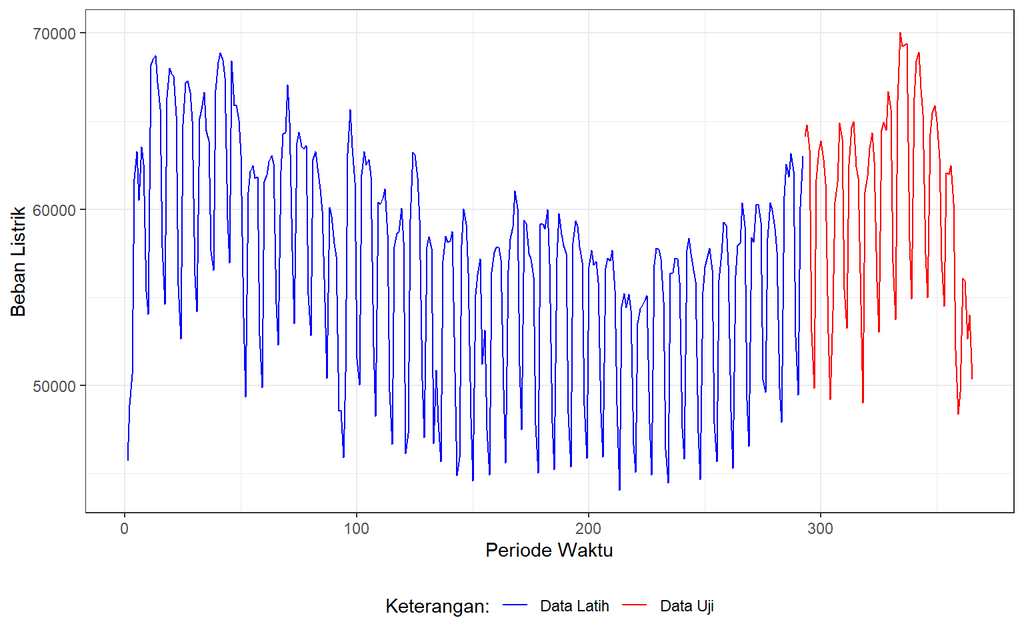

```r
#Eksplorasi dengan GGPLOT
library(ggplot2)
ggplot() +
  geom_line(data = training, aes(x = Periode, y = , Beban_Listrik, col = "Data Latih")) +
  geom_line(data = testing, aes(x = Periode, y = Beban_Listrik, col = "Data Uji")) +
  labs(x = "Periode Waktu", y = "Beban Listrik", color = "Legend") +
  scale_colour_manual(name="Keterangan:", breaks = c("Data Latih", "Data Uji"),
                      values = c("blue", "red")) +
  theme_bw() + theme(legend.position = "bottom",
                     plot.caption = element_text(hjust=0.5, size=12))
```

## Single Exponential Smoothing

Single Exponential Smoothing (SES) adalah metode peramalan deret waktu yang dikembangkan untuk mengatasi kelemahan Moving Average. Jika pada Moving Average setiap data periode sebelumnya dianggap memiliki bobot yang sama, maka SES memberikan bobot yang semakin mengecil secara eksponensial terhadap data lama, sehingga data terbaru diberi bobot lebih besar.

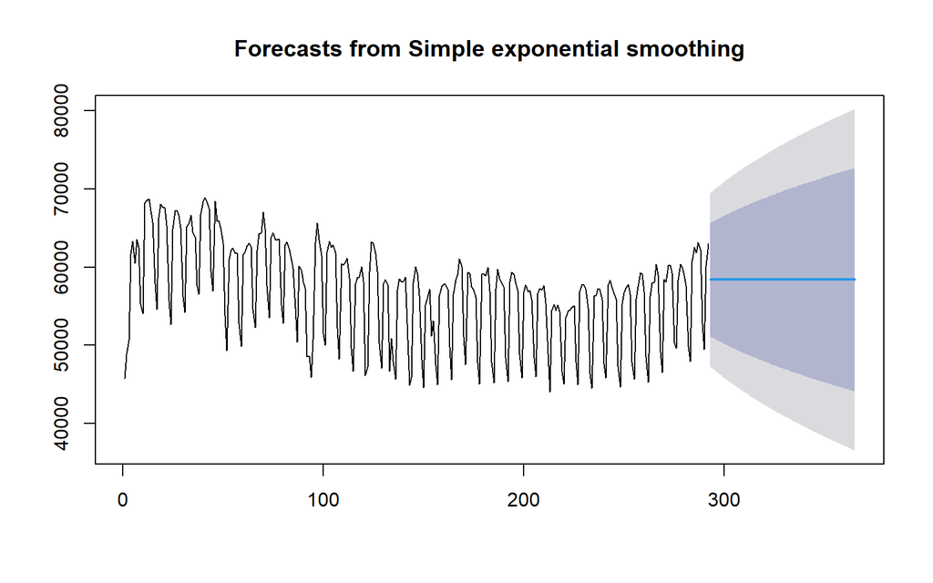

```r
#Cara 1 (fungsi ses)
h_test <- length(test.ts)

ses.1 <- ses(train.ts, h = h_test, alpha = 0.2)
plot(ses.1)
```

```r
ses.1
```

```
##     Point Forecast    Lo 80    Hi 80    Lo 95    Hi 95
## 293       58395.46 51151.00 65639.92 47316.01 69474.91
## 294       58395.46 51007.53 65783.39 47096.60 69694.33
## 295       58395.46 50866.80 65924.13 46881.36 69909.56
## 296       58395.46 50728.64 66062.28 46670.07 70120.85
## 297       58395.46 50592.94 66197.99 46462.53 70328.39
## 298       58395.46 50459.55 66331.37 46258.53 70532.39
## 299       58395.46 50328.37 66462.55 46057.91 70733.01
## 300       58395.46 50199.29 66591.64 45860.50 70930.43
## 301       58395.46 50072.21 66718.72 45666.14 71124.78
## 302       58395.46 49947.04 66843.88 45474.71 71316.21
## 303       58395.46 49823.70 66967.23 45286.08 71504.84
## 304       58395.46 49702.11 67088.82 45100.12 71690.80
## 305       58395.46 49582.19 67208.73 44916.73 71874.19
## 306       58395.46 49463.89 67327.04 44735.80 72055.12
```

[output cut: 59 more lines]

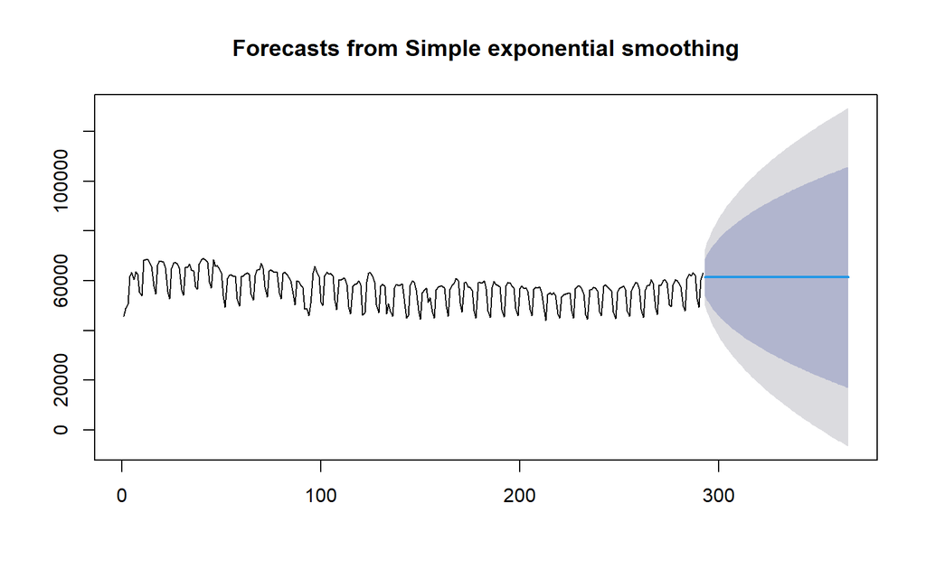

```r
ses.2<- ses(train.ts, h = h_test, alpha = 0.7)
plot(ses.2)
```

```r
ses.2
```

```
##     Point Forecast    Lo 80     Hi 80      Lo 95     Hi 95
## 293       61356.35 53979.97  68732.74 50075.1470  72637.56
## 294       61356.35 52352.33  70360.38 47585.8862  75126.82
## 295       61356.35 50976.86  71735.85 45482.2891  77230.42
## 296       61356.35 49763.46  72949.25 43626.5462  79086.16
## 297       61356.35 48665.54  74047.16 41947.4324  80765.27
## 298       61356.35 47655.33  75057.38 40402.4430  82310.26
## 299       61356.35 46714.65  75998.06 38963.7986  83748.91
## 300       61356.35 45830.86  76881.85 37612.1613  85100.54
## 301       61356.35 44994.74  77717.96 36333.4278  86379.28
## 302       61356.35 44199.32  78513.38 35116.9374  87595.77
## 303       61356.35 43439.18  79273.53 33954.3991  88758.31
## 304       61356.35 42710.00  80002.71 32839.2139  89873.49
## 305       61356.35 42008.28  80704.43 31766.0274  90946.68
## 306       61356.35 41331.13  81381.57 30730.4241  91982.28
```

[output cut: 59 more lines]

Untuk mendapatkan gambar hasil pemulusan pada data latih dengan fungsi `ses()` , perlu digunakan fungsi `autoplot()` dan `autolayer()` dari *library packages* `ggplot2` .

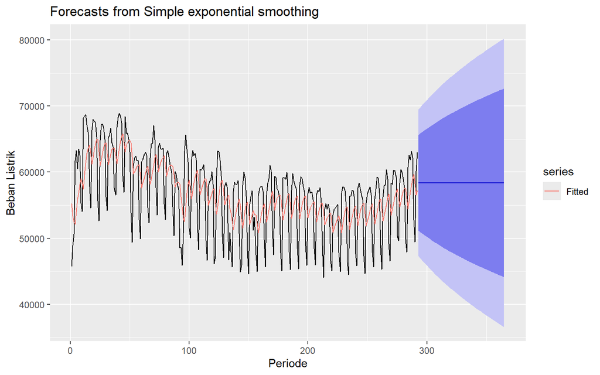

```r
autoplot(ses.1) +
  autolayer(fitted(ses.1), series="Fitted") +
  ylab("Beban Listrik") + xlab("Periode")
```

Selanjutnya akan digunakan fungsi `HoltWinters()` dengan nilai inisialisasi parameter dan panjang periode peramalan yang sama dengan fungsi `ses()` .

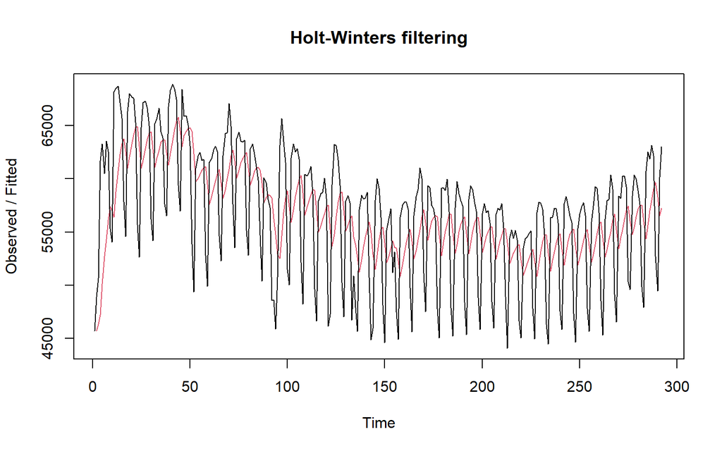

```r
#Cara 2 (fungsi Holtwinter)
ses1<- HoltWinters(train.ts, gamma = FALSE, beta = FALSE, alpha = 0.2)
plot(ses1)
```

```r
#ramalan
ramalan1<- forecast(ses1, h=h_test)
ramalan1
```

```
##     Point Forecast    Lo 80    Hi 80    Lo 95    Hi 95
## 293       58395.46 51058.06 65732.86 47173.87 69617.05
## 294       58395.46 50912.75 65878.17 46951.64 69839.28
## 295       58395.46 50770.21 66020.71 46733.64 70057.28
## 296       58395.46 50630.28 66160.64 46519.65 70271.28
## 297       58395.46 50492.84 66298.09 46309.44 70481.48
## 298       58395.46 50357.74 66433.18 46102.83 70688.10
## 299       58395.46 50224.88 66566.05 45899.63 70891.29
## 300       58395.46 50094.14 66696.79 45699.68 71091.24
## 301       58395.46 49965.43 66825.50 45502.84 71288.09
## 302       58395.46 49838.65 66952.27 45308.95 71481.97
## 303       58395.46 49713.73 67077.19 45117.90 71673.03
## 304       58395.46 49590.58 67200.35 44929.55 71861.37
## 305       58395.46 49469.13 67321.80 44743.81 72047.11
## 306       58395.46 49349.30 67441.62 44560.56 72230.37
```

[output cut: 59 more lines]

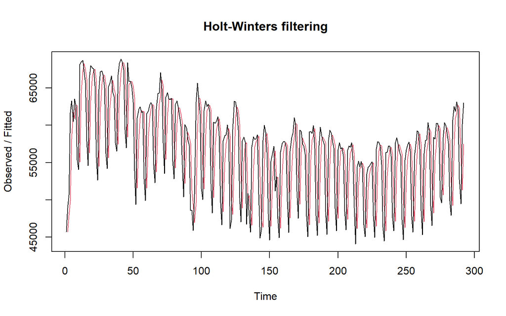

```r
ses2<- HoltWinters(train.ts, gamma = FALSE, beta = FALSE, alpha = 0.7)
plot(ses2)
```

```r
#ramalan
ramalan2<- forecast(ses2, h=h_test)
ramalan2
```

```
##     Point Forecast    Lo 80     Hi 80      Lo 95     Hi 95
## 293       61356.35 53979.78  68732.93 50074.8590  72637.85
## 294       61356.35 52352.10  70360.61 47585.5346  75127.17
## 295       61356.35 50976.60  71736.11 45481.8839  77230.82
## 296       61356.35 49763.16  72949.55 43626.0935  79086.61
## 297       61356.35 48665.22  74047.49 41946.9369  80765.77
## 298       61356.35 47654.98  75057.73 40401.9080  82310.80
## 299       61356.35 46714.27  75998.43 38963.2269  83749.48
## 300       61356.35 45830.46  76882.24 37611.5551  85101.15
## 301       61356.35 44994.32  77718.38 36332.7890  86379.92
## 302       61356.35 44198.88  78513.82 35116.2675  87596.44
## 303       61356.35 43438.72  79273.98 33953.6995  88759.01
## 304       61356.35 42709.52  80003.18 32838.4858  89874.22
## 305       61356.35 42007.78  80704.92 31765.2719  90947.43
## 306       61356.35 41330.62  81382.08 30729.6422  91983.06
```

[output cut: 59 more lines]

Fungsi `HoltWinters` memiliki argumen yang sama dengan fungsi `ses()` . Argumen-argumen kedua fungsi dapat dilihat lebih lanjut dengan `?ses()` atau `?HoltWinters` .

Nilai parameter $\alpha$ dari kedua fungsi dapat dioptimalkan menyesuaikan dari *error*-nya paling minimumnya. Caranya adalah dengan membuat parameter $\alpha =$ `NULL` .

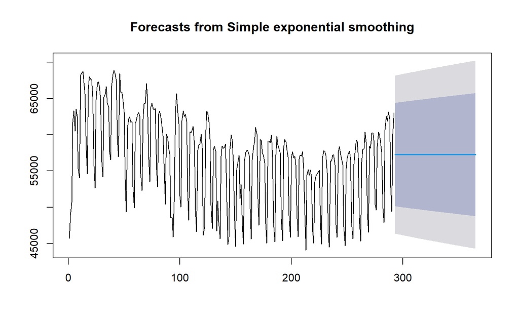

```r
#SES
ses.opt <- ses(train.ts, h = h_test, alpha = NULL)
plot(ses.opt)
```

```r
ses.opt
```

```
##     Point Forecast    Lo 80    Hi 80    Lo 95    Hi 95
## 293       57261.01 50131.36 64390.66 46357.15 68164.87
## 294       57261.01 50110.87 64411.15 46325.82 68196.20
## 295       57261.01 50090.44 64431.58 46294.57 68227.45
## 296       57261.01 50070.07 64451.95 46263.42 68258.60
## 297       57261.01 50049.76 64472.26 46232.35 68289.67
## 298       57261.01 50029.50 64492.52 46201.38 68320.65
## 299       57261.01 50009.30 64512.72 46170.48 68351.54
## 300       57261.01 49989.16 64532.86 46139.68 68382.35
## 301       57261.01 49969.07 64552.95 46108.95 68413.07
## 302       57261.01 49949.04 64572.98 46078.32 68443.70
## 303       57261.01 49929.06 64592.96 46047.76 68474.26
## 304       57261.01 49909.14 64612.88 46017.29 68504.73
## 305       57261.01 49889.27 64632.75 45986.91 68535.12
## 306       57261.01 49869.45 64652.57 45956.60 68565.42
```

[output cut: 59 more lines]

```r
#Lamda Optimum Holt Winter
HWopt<- HoltWinters(train.ts, gamma = FALSE, beta = FALSE,alpha = NULL)
HWopt
```

```
## Holt-Winters exponential smoothing without trend and without seasonal component.
##
## Call:
## HoltWinters(x = train.ts, alpha = NULL, beta = FALSE, gamma = FALSE)
##
## Smoothing parameters:
##  alpha: 0.9999339
##  beta : FALSE
##  gamma: FALSE
##
## Coefficients:
##       [,1]
## a 63009.85
```

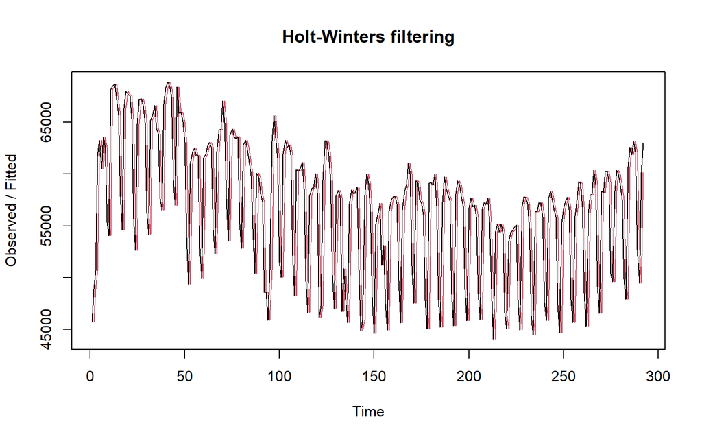

```r
plot(HWopt)
```

```r
#ramalan
ramalanopt<- forecast(HWopt, h=h_test)
ramalanopt
```

```
##     Point Forecast     Lo 80     Hi 80       Lo 95     Hi 95
## 293       63009.85 55820.674  70199.03  52014.9541  74004.75
## 294       63009.85 52843.156  73176.55  47461.2326  78558.47
## 295       63009.85 50558.381  75461.32  43966.9702  82052.73
## 296       63009.85 48632.211  77387.49  41021.1474  84998.55
## 297       63009.85 46935.213  79084.49  38425.8143  87593.89
## 298       63009.85 45401.007  80618.70  36079.4474  89940.25
## 299       63009.85 43990.155  82029.55  33921.7364  92097.97
## 300       63009.85 42676.965  83342.74  31913.3851  94106.32
## 301       63009.85 41443.588  84576.11  30027.0985  95992.60
## 302       63009.85 40277.031  85742.67  28243.0027  97776.70
## 303       63009.85 39167.482  86852.22  26546.0948  99473.61
## 304       63009.85 38107.322  87912.38  24924.7188 101094.98
## 305       63009.85 37090.488  88929.21  23369.6054 102650.10
## 306       63009.85 36112.066  89907.64  21873.2390 104146.46
```

[output cut: 59 more lines]

Setelah dilakukan peramalan, akan dilakukan perhitungan keakuratan hasil peramalan. Perhitungan akurasi ini dilakukan baik pada data latih dan data uji.

#### Akurasi Data Latih

Perhitungan akurasi data dapat dilakukan dengan cara langsung maupun manual. Secara langsung, nilai akurasi dapat diambil dari objek yang tersimpan pada hasil SES, yaitu *sum of squared errors* (SSE). Nilai akurasi lain dapat dihitung pula dari nilai SSE tersebut.

```r
#Keakuratan Metode
#Pada data training

# SES dengan alpha = 0.2
SSE1<-ses1$SSE
MSE1<-ses1$SSE/length(train.ts)
RMSE1<-sqrt(MSE1)

akurasi1 <- matrix(c(SSE1,MSE1,RMSE1))
row.names(akurasi1)<- c("SSE", "MSE", "RMSE")
colnames(akurasi1) <- c("Akurasi lamda=0.2")
akurasi1
```

```
##      Akurasi lamda=0.2
## SSE       9.520088e+09
## MSE       3.260304e+07
## RMSE      5.709907e+03
```

```r
# SES dengan alpha = 0.7
SSE2<-ses2$SSE
MSE2<-ses2$SSE/length(train.ts)
RMSE2<-sqrt(MSE2)

akurasi2 <- matrix(c(SSE2,MSE2,RMSE2))
row.names(akurasi2)<- c("SSE", "MSE", "RMSE")
colnames(akurasi2) <- c("Akurasi lamda=0.7")
akurasi2
```

```
##      Akurasi lamda=0.7
## SSE       9.609761e+09
## MSE       3.291014e+07
## RMSE      5.736736e+03
```

```r
#Cara Manual
# Alpha = 0.2
fitted1<-ramalan1$fitted
sisaan1<-ramalan1$residuals
head(sisaan1)
```

```
## Time Series:
## Start = 1
## End = 6
## Frequency = 1
## [1]        NA  3174.720  4294.716 14505.123 13178.148  7776.339
```

```r
resid1<-training$Beban_Listrik-ramalan1$fitted
head(resid1)
```

```
## Time Series:
## Start = 1
## End = 6
## Frequency = 1
## [1]        NA  3174.720  4294.716 14505.123 13178.148  7776.339
```

```r
SSE.1=sum(sisaan1[2:length(train.ts)]^2)
SSE.1
```

```
## [1] 9520088485
```

```r
MSE.1 = SSE.1/length(train.ts)
MSE.1
```

```
## [1] 32603043
```

```r
MAPE.1 = sum(abs(sisaan1[2:length(train.ts)]/train.ts[2:length(train.ts)])*
               100)/length(train.ts)
MAPE.1
```

```
## [1] 9.044605
```

```r
akurasi.1 <- matrix(c(SSE.1,MSE.1,MAPE.1))
row.names(akurasi.1)<- c("SSE", "MSE", "MAPE")
colnames(akurasi.1) <- c("Akurasi lamda=0.2")
akurasi.1
```

```
##      Akurasi lamda=0.2
## SSE       9.520088e+09
## MSE       3.260304e+07
## MAPE      9.044605e+00
```

```r
# Alpha = 0.7
fitted2<-ramalan2$fitted
sisaan2<-ramalan2$residuals
head(sisaan2)
```

```
## Time Series:
## Start = 1
## End = 6
## Frequency = 1
## [1]        NA  3174.720  2707.356 11881.557  5138.517 -1224.625
```

```r
resid2<-training$Beban_Listrik-ramalan2$fitted
head(resid2)
```

```
## Time Series:
## Start = 1
## End = 6
## Frequency = 1
## [1]        NA  3174.720  2707.356 11881.557  5138.517 -1224.625
```

```r
SSE.2=sum(sisaan2[2:length(train.ts)]^2)
SSE.2
```

```
## [1] 9609760522
```

```r
MSE.2 = SSE.2/length(train.ts)
MSE.2
```

```
## [1] 32910139
```

```r
MAPE.2 = sum(abs(sisaan2[2:length(train.ts)]/train.ts[2:length(train.ts)])*
               100)/length(train.ts)
MAPE.2
```

```
## [1] 8.207401
```

```r
akurasi.2 <- matrix(c(SSE.2,MSE.2,MAPE.2))
row.names(akurasi.2)<- c("SSE", "MSE", "MAPE")
colnames(akurasi.2) <- c("Akurasi lamda=0.7")
akurasi.2
```

```
##      Akurasi lamda=0.7
## SSE       9.609761e+09
## MSE       3.291014e+07
## MAPE      8.207401e+00
```

#### Akurasi Data Uji

Akurasi data uji dapat dihitung dengan cara yang hampir sama dengan perhitungan akurasi data latih.

```r
# jumlah observasi uji
n_test <- nrow(testing)

# error (ramalan - aktual), samakan panjang dan tipe numeric
e1   <- as.numeric(ramalan1$mean)[1:n_test] - as.numeric(testing$Beban_Listrik)
e2   <- as.numeric(ramalan2$mean)[1:n_test] - as.numeric(testing$Beban_Listrik)
eopt <- as.numeric(ramalanopt$mean)[1:n_test] - as.numeric(testing$Beban_Listrik)

# SSE / MSE / RMSE untuk masing-masing model (abaikan NA)
SSEtesting1  <- sum(e1^2,  na.rm = TRUE)
MSEtesting1  <- mean(e1^2, na.rm = TRUE)
RMSEtesting1 <- sqrt(MSEtesting1)

SSEtesting2  <- sum(e2^2,  na.rm = TRUE)
MSEtesting2  <- mean(e2^2, na.rm = TRUE)
RMSEtesting2 <- sqrt(MSEtesting2)

SSEtestingopt  <- sum(eopt^2,  na.rm = TRUE)
MSEtestingopt  <- mean(eopt^2, na.rm = TRUE)
RMSEtestingopt <- sqrt(MSEtestingopt)

# Tabel ringkas
akurasitesting_SSE <- matrix(c(SSEtesting1, SSEtesting2, SSEtestingopt),
                             nrow = 3,
                             dimnames = list(c("SSE1","SSE2","SSEopt"), "Nilai"))
akurasitesting_MSE <- matrix(c(MSEtesting1, MSEtesting2, MSEtestingopt),
                             nrow = 3,
                             dimnames = list(c("MSE1","MSE2","MSEopt"), "Nilai"))
akurasitesting_RMSE <- matrix(c(RMSEtesting1, RMSEtesting2, RMSEtestingopt),
                              nrow = 3,
                              dimnames = list(c("RMSE1","RMSE2","RMSEopt"), "Nilai"))

akurasitesting_SSE
```

```
##             Nilai
## SSE1   2767036607
## SSE2   2533332515
## SSEopt 2959802960
```

```r
akurasitesting_MSE
```

```
##           Nilai
## MSE1   37904611
## MSE2   34703185
## MSEopt 40545246
```

```r
akurasitesting_RMSE
```

```
##            Nilai
## RMSE1   6156.672
## RMSE2   5890.941
## RMSEopt 6367.515
```

Selain dengan cara di atas, perhitungan nilai akurasi dapat menggunakan fungsi `accuracy()` dari *package* `forecast` . Penggunaannya yaitu dengan menuliskan `accuracy(hasil ramalan, kondisi aktual)` .

```r
accuracy(ramalan1, testing$Beban_Listrik)
```

```
##                     ME     RMSE      MAE        MPE     MAPE     MASE      ACF1
## Training set  217.8433 5719.710 4943.284 -0.5684774 9.075686 1.278724 0.4237709
## Test set     2021.0642 6156.672 5565.170  2.3942943 9.217250 1.439593        NA
```

```r
accuracy(ramalan2, testing$Beban_Listrik)
```

```
##                     ME     RMSE      MAE        MPE     MAPE    MASE      ACF1
## Training set   76.7765 5746.584 4508.523 -0.5794255 8.235605 1.16626 0.2331813
## Test set     -939.8269 5890.941 4858.067 -2.5547182 8.469972 1.25668        NA
```

```r
accuracy(ramalanopt, testing$Beban_Listrik)
```

```
##                      ME     RMSE      MAE        MPE     MAPE     MASE
## Training set    59.4296 5600.413 3865.918 -0.4184201 7.020712 1.000032
## Test set     -2593.3252 6367.515 4858.606 -5.3184752 8.694825 1.256819
##                    ACF1
## Training set 0.06908771
## Test set             NA
```

## *Double Exponential Smoothing* (DES)

Metode pemulusan *Double Exponential Smoothing* (DES) digunakan untuk data yang memiliki pola tren. Metode DES adalah metode semacam SES, hanya saja dilakukan dua kali, yaitu pertama untuk tahapan ‘level’ dan kedua untuk tahapan ‘tren’. Pemulusan menggunakan metode ini akan menghasilkan peramalan tidak konstan untuk periode berikutnya.

Pemulusan dengan metode DES kali ini akan menggunakan fungsi `HoltWinters()` . Jika sebelumnya nilai argumen `beta` dibuat `FALSE` , kali ini argumen tersebut akan diinisialisasi bersamaan dengan nilai `alpha` .

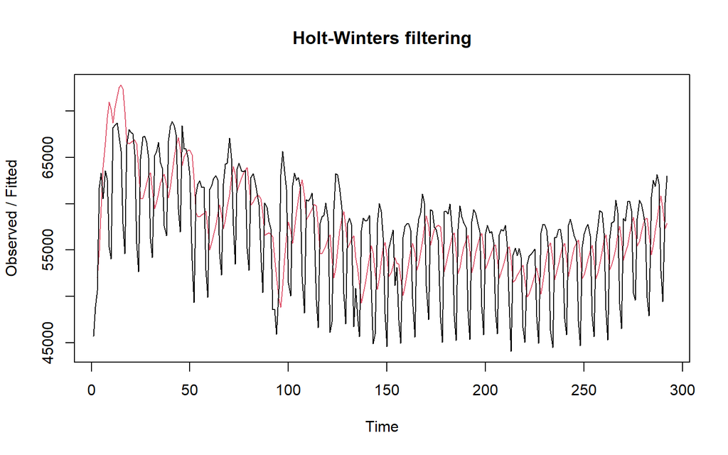

```r
#Lamda=0.2 dan gamma=0.2
des.1<- HoltWinters(train.ts, gamma = FALSE, beta = 0.2, alpha = 0.2)
plot(des.1)
```

```r
#ramalan
ramalandes1<- forecast(des.1, h=h_test)
ramalandes1
```

```
##     Point Forecast       Lo 80     Hi 80        Lo 95     Hi 95
## 293       59079.26  51308.6676  66849.86   47195.1630  70963.36
## 294       59257.61  51266.3580  67248.87   47036.0430  71479.18
## 295       59435.96  51153.8071  67718.12   46769.4981  72102.43
## 296       59614.31  50966.9303  68261.70   46389.2817  72839.35
## 297       59792.67  50704.0580  68881.27   45892.8400  73692.49
## 298       59971.02  50365.6045  69576.43   45280.8070  74661.22
## 299       60149.37  49953.5874  70345.15   44556.2681  75742.46
## 300       60327.72  49471.1081  71184.33   43723.9666  76931.47
## 301       60506.07  48921.8849  72090.25   42789.5890  78222.55
## 302       60684.42  48309.8826  73058.95   41759.1992  79609.64
## 303       60862.77  47639.0513  74086.49   40638.8381  81086.70
## 304       61041.12  46913.1601  75169.08   39434.2703  82647.97
## 305       61219.47  46135.7059  76303.23   38150.8436  84288.10
## 306       61397.82  45309.8734  77485.77   36793.4286  86002.21
```

[output cut: 59 more lines]

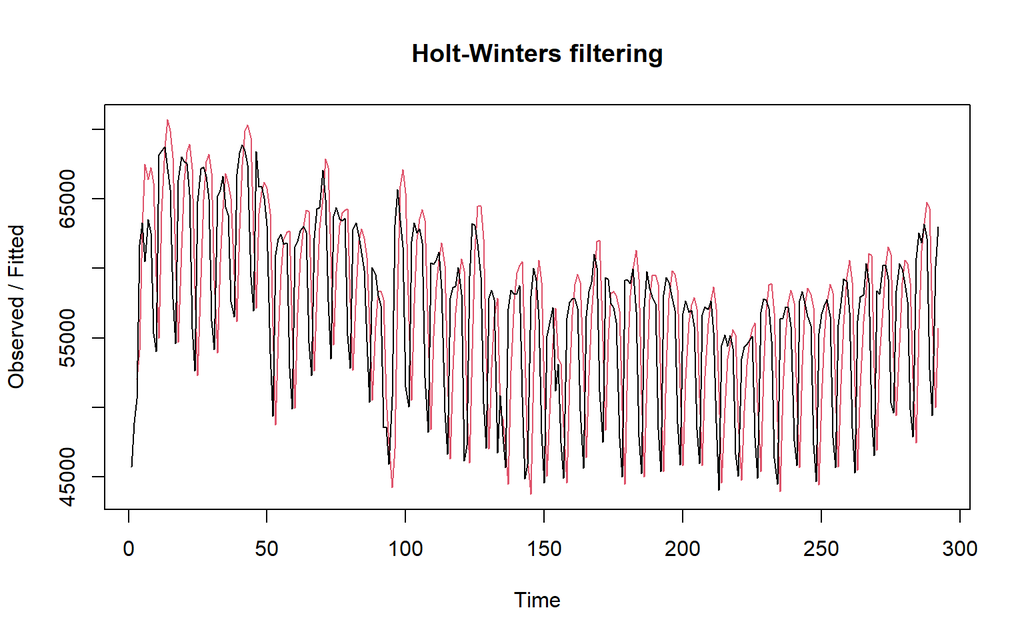

```r
#Lamda=0.6 dan gamma=0.3
des.2<- HoltWinters(train.ts, gamma = FALSE, beta = 0.3, alpha = 0.6)
plot(des.2)
```

```r
#ramalan
ramalandes2<- forecast(des.2, h=h_test)
ramalandes2
```

```
##     Point Forecast       Lo 80     Hi 80        Lo 95      Hi 95
## 293       61003.38   52371.284  69635.48   47801.7260   74205.04
## 294       61921.27   50973.809  72868.73   45178.5728   78663.97
## 295       62839.16   49108.966  76569.36   41840.6402   83837.68
## 296       63757.05   46864.581  80649.52   37922.2473   89591.85
## 297       64674.94   44298.796  85051.08   33512.3167   95837.56
## 298       65592.83   41450.711  89734.94   28670.6469  102515.01
## 299       66510.72   38347.839  94673.60   23439.3123  109582.12
## 300       67428.61   35010.504  99846.71   17849.3972  117007.82
## 301       68346.50   31454.392 105238.60   11924.8929  124768.10
## 302       69264.38   27692.064 110836.70    5685.0069  132843.76
## 303       70182.27   23733.877 116630.67    -854.4187  141218.97
## 304       71100.16   19588.583 122611.74   -7679.9998  149880.32
## 305       72018.05   15263.720 128772.38  -14780.2080  158816.31
## 306       72935.94   10765.884 135106.00  -22144.9558  168016.84
```

[output cut: 59 more lines]

Selanjutnya jika ingin membandingkan plot data latih dan data uji adalah sebagai berikut.

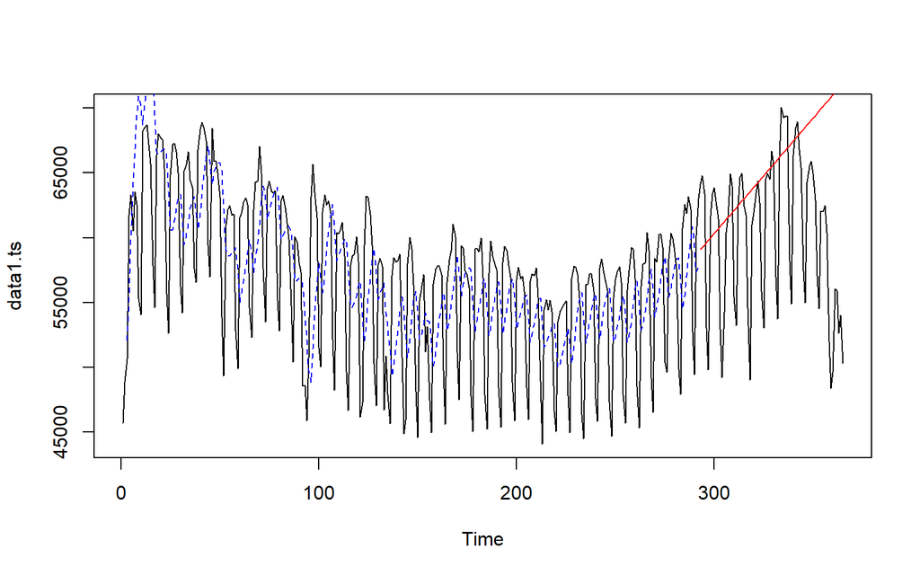

```r
plot(data1.ts)
lines(des.1$fitted[,1], lty=2, col="blue")
lines(ramalandes1$mean, col="red")
```

Untuk mendapatkan nilai parameter optimum dari DES, argumen `alpha` dan `beta` dapat dibuat `NULL` seperti berikut.

```r
#Lamda dan gamma optimum
des.opt<- HoltWinters(train.ts, gamma = FALSE)
des.opt
```

```
## Holt-Winters exponential smoothing with trend and without seasonal component.
##
## Call:
## HoltWinters(x = train.ts, gamma = FALSE)
##
## Smoothing parameters:
##  alpha: 0.2516917
##  beta : 0.1119996
##  gamma: FALSE
##
## Coefficients:
##         [,1]
## a 58954.5423
## b   165.9562
```

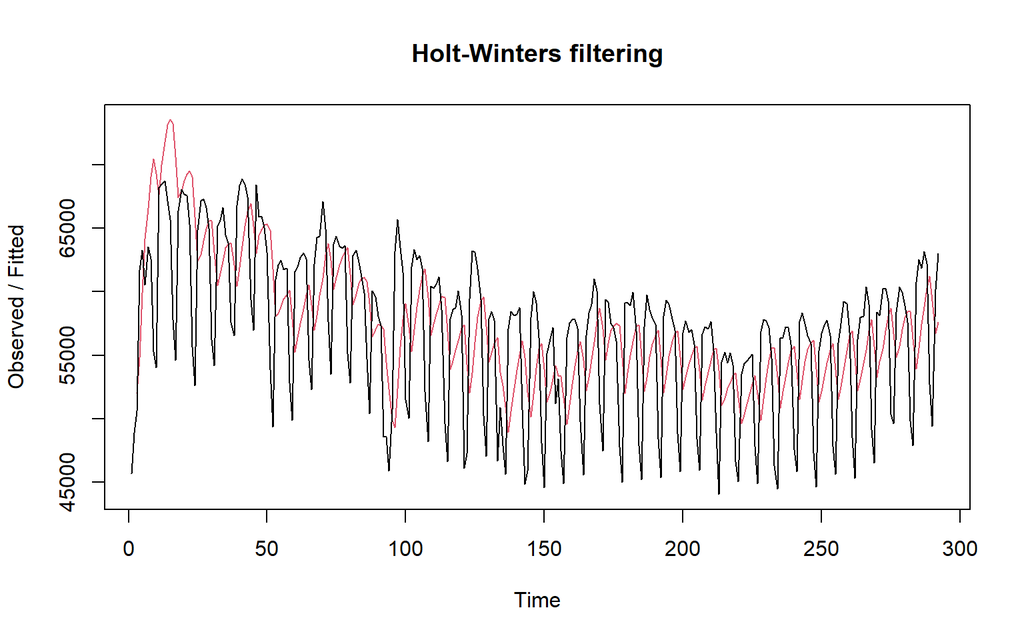

```r
plot(des.opt)
```

```r
#ramalan
ramalandesopt<- forecast(des.opt, h=h_test)
ramalandesopt
```

```
##     Point Forecast       Lo 80     Hi 80        Lo 95     Hi 95
## 293       59120.50  51391.4944  66849.50  47300.00675  70940.99
## 294       59286.45  51260.4378  67312.47  47011.72105  71561.19
## 295       59452.41  51080.6442  67824.18  46648.89846  72255.92
## 296       59618.37  50852.4651  68384.27  46212.07680  73024.66
## 297       59784.32  50576.9586  68991.69  45702.87403  73865.77
## 298       59950.28  50255.6934  69644.87  45123.68942  74776.87
## 299       60116.24  49890.5680  70341.90  44477.42630  75755.05
## 300       60282.19  49483.6574  71080.73  43767.25827  76797.13
## 301       60448.15  49037.0946  71859.20  42996.44748  77899.85
## 302       60614.10  48552.9848  72675.22  42168.21358  79060.00
## 303       60780.06  48033.3484  73526.77  41285.64632  80274.48
## 304       60946.02  47480.0863  74411.95  40351.65305  81540.38
## 305       61111.97  46894.9627  75328.98  39368.93184  82855.02
## 306       61277.93  46279.5992  76276.26  38339.96260  84215.90
```

[output cut: 59 more lines]

Selanjutnya akan dilakukan perhitungan akurasi pada data latih maupun data uji dengan ukuran akurasi SSE, MSE dan MAPE.

#### Akurasi Data Latih

```r
#Akurasi Data Training
ssedes.train1<-des.1$SSE
msedes.train1<-ssedes.train1/length(train.ts)
sisaandes1<-ramalandes1$residuals
head(sisaandes1)
```

```
## Time Series:
## Start = 1
## End = 6
## Frequency = 1
## [1]        NA        NA -1419.780  6815.597  3635.975 -3393.392
```

```r
mapedes.train1 <- sum(abs(sisaandes1[3:length(train.ts)]/train.ts[3:length(train.ts)])
                      *100)/length(train.ts)

akurasides.1 <- matrix(c(ssedes.train1,msedes.train1,mapedes.train1))
row.names(akurasides.1)<- c("SSE", "MSE", "MAPE")
colnames(akurasides.1) <- c("Akurasi lamda=0.2 dan gamma=0.2")
akurasides.1
```

```
##      Akurasi lamda=0.2 dan gamma=0.2
## SSE                     1.064448e+10
## MSE                     3.645370e+07
## MAPE                    9.382940e+00
```

```r
ssedes.train2<-des.2$SSE
msedes.train2<-ssedes.train2/length(train.ts)
sisaandes2<-ramalandes2$residuals
head(sisaandes2)
```

```
## Time Series:
## Start = 1
## End = 6
## Frequency = 1
## [1]         NA         NA -1419.7800  7582.2784   322.9916 -6979.0915
```

```r
mapedes.train2 <- sum(abs(sisaandes2[3:length(train.ts)]/train.ts[3:length(train.ts)])
                      *100)/length(train.ts)

akurasides.2 <- matrix(c(ssedes.train2,msedes.train2,mapedes.train2))
row.names(akurasides.2)<- c("SSE", "MSE", "MAPE")
colnames(akurasides.2) <- c("Akurasi lamda=0.6 dan gamma=0.3")
akurasides.2
```

```
##      Akurasi lamda=0.6 dan gamma=0.3
## SSE                     1.311223e+10
## MSE                     4.490489e+07
## MAPE                    9.742436e+00
```

#### Akurasi Data Uji

```r
#Akurasi Data Testing
selisihdes1<-ramalandes1$mean-testing$Beban_Listrik
selisihdes1
```

```
## Time Series:
## Start = 293
## End = 365
## Frequency = 1
##  [1] -5042.96731 -5551.29671 -3960.28611  6577.05449  9963.27509 -1728.82431
##  [7] -3201.70372 -3544.52312 -2308.92252  -790.16192  7913.85868 11848.04928
## [13]  6989.70988  1007.66048    21.86108 -3158.80832 -2063.48772  6675.39288
## [19]  9039.51348  -108.06592 -1998.96532 -2155.08472   578.48588  1422.01648
## [25]  8767.48708 14511.12768  2729.40828  1987.92888   622.95948  -100.90992
## [31]  1712.89068  8723.95128 11753.69187   471.90247   187.54307   823.39367
## [37] -1182.78573    14.34487  8885.25547 12279.98607    41.52667 -3644.30273
## [43] -2696.72213 -2602.17153 -2498.65093  8899.84967 12365.45027  1112.46087
## [49]  -788.72853 -1114.03793  1175.85267  2763.62327 10895.42387 13522.39447
## [55]  4427.57507  3430.28567  3193.19627  4255.90687  6539.04746 12538.40806
## [61] 15264.25866  7905.47926  8135.36986  7821.24046 10121.01106 18678.66166
## [67] 22472.58226 21401.48286 15133.85346 15463.87406 18931.14466 17737.07526
## [73] 21590.78586
```

```r
SSEtestingdes1<-sum(selisihdes1^2)
MSEtestingdes1<-SSEtestingdes1/length(testing$Beban_Listrik)
MAPEtestingdes1<-sum(abs(selisihdes1/testing$Beban_Listrik)*100)/length(testing$Beban_Listrik)

selisihdes2<-ramalandes2$mean-testing$Beban_Listrik
selisihdes2
```

```
## Time Series:
## Start = 293
## End = 365
## Frequency = 1
##  [1] -3118.8470 -2887.6379  -557.0889 10719.7901 14845.5491  3892.9882
##  [7]  3159.6472  3556.3662  5531.5053  7789.8043 17233.3633 21907.0923
## [13] 17788.2914 12545.7804 12299.5194  9858.3885 11693.2475 21171.6665
## [19] 24275.3255 15867.2846 14715.9236 15299.3426 18772.4517 20355.5207
## [25] 28440.5297 34923.7087 23881.5278 23879.5868 23254.1558 23269.8249
## [31] 25823.1639 33573.7629 37343.0419 26800.7910 27255.9700 28631.3590
## [37] 27364.7181 29301.3871 38911.8361 43046.1051 31547.1842 28600.8932
## [43] 30288.0122 31122.1013 31965.1603 44103.1993 48308.3383 37794.8874
## [49] 36633.2364 37047.4654 40076.8945 42404.2035 51275.5425 54642.0515
## [55] 46286.7706 46029.0196 46531.4686 48333.7177 51356.3967 58095.2957
## [61] 61560.6847 54941.4438 55910.8728 56336.2818 59375.5909 68672.7799
## [67] 73206.2389 72874.6779 67346.5870 68416.1460 72622.9550 72168.4241
## [73] 76761.6731
```

```r
SSEtestingdes2<-sum(selisihdes2^2)
MSEtestingdes2<-SSEtestingdes2/length(testing$Beban_Listrik)
MAPEtestingdes2<-sum(abs(selisihdes2/testing$Beban_Listrik)*100)/length(testing$Beban_Listrik)

selisihdesopt<-ramalandesopt$mean-testing$Beban_Listrik
selisihdesopt
```

```
## Time Series:
## Start = 293
## End = 365
## Frequency = 1
##  [1] -5001.7314 -5522.4552 -3943.8389  6581.1073  9954.9336 -1749.5602
##  [7] -3234.8340 -3590.0477 -2366.8415  -860.4752  7831.1510 11752.9472
## [13]  6882.2135   887.7697  -110.4240 -3303.4878 -2220.5615  6505.9247
## [19]  8857.6509  -302.3228 -2205.6166 -2374.1303   347.0459  1178.1821
## [25]  8511.2584 14242.5046  2448.3909  1694.5171   317.1534  -419.1104
## [31]  1382.2958  8380.9621 11398.3083   104.1246  -192.6292   430.8270
## [37] -1587.7467  -403.0105  8455.5058 11837.8420  -413.0118 -4111.2355
## [43] -3176.0493 -3093.8930 -3002.7668  8383.3395 11836.5457   571.1619
## [49] -1342.4218 -1680.1256   597.3707  2172.7469 10292.1531 12906.7294
## [55]  3799.5156  2789.8319  2540.3481  3590.6644  5861.4106 11848.3768
## [61] 14561.8331  7190.6593  7408.1556  7081.6318  9369.0080 17914.2643
## [67] 21695.7905 20612.2968 14332.2730 14649.8993 18104.7755 16898.3117
## [73] 20739.6280
```

```r
SSEtestingdesopt<-sum(selisihdesopt^2)
MSEtestingdesopt<-SSEtestingdesopt/length(testing$Beban_Listrik)
MAPEtestingdesopt<-sum(abs(selisihdesopt/testing$Beban_Listrik)*100)/length(testing$Beban_Listrik)

akurasitestingdes <-
  matrix(c(SSEtestingdes1,MSEtestingdes1,MAPEtestingdes1,SSEtestingdes2,MSEtestingdes2,
           MAPEtestingdes2,SSEtestingdesopt,MSEtestingdesopt,MAPEtestingdesopt),
         nrow=3,ncol=3)
row.names(akurasitestingdes)<- c("SSE", "MSE", "MAPE")
colnames(akurasitestingdes) <- c("des ske1","des ske2","des opt")
akurasitestingdes
```

```
##          des ske1     des ske2      des opt
## SSE  5.682679e+09 1.138680e+11 5.235180e+09
## MSE  7.784492e+07 1.559836e+09 7.171480e+07
## MAPE 1.165322e+01 5.782030e+01 1.121565e+01
```

#### Perbandingan SES dan DES

```r
MSEfull <-
  matrix(c(MSEtesting1,MSEtesting2,MSEtestingopt,MSEtestingdes1,MSEtestingdes2,
           MSEtestingdesopt),nrow=3,ncol=2)
row.names(MSEfull)<- c("ske 1", "ske 2", "ske opt")
colnames(MSEfull) <- c("ses","des")
MSEfull
```

```
##              ses        des
## ske 1   37904611   77844921
## ske 2   34703185 1559835507
## ske opt 40545246   71714799
```

## Pemulusan Data Musiman

```r
data3.ts <- data1.ts
```

Selanjutnya melakukan pembagian data dan mengubahnya menjadi data deret waktu.

```r
#membagi data menjadi training dan testing
training.ts <- ts(data1$Beban_Listrik[1:n_train], frequency = 7)
testing.ts  <- ts(data1$Beban_Listrik[(n_train+1):n], frequency = 7)
```

Kemudian akan dilakukan eskplorasi dengan plot data deret waktu sebagai berikut.

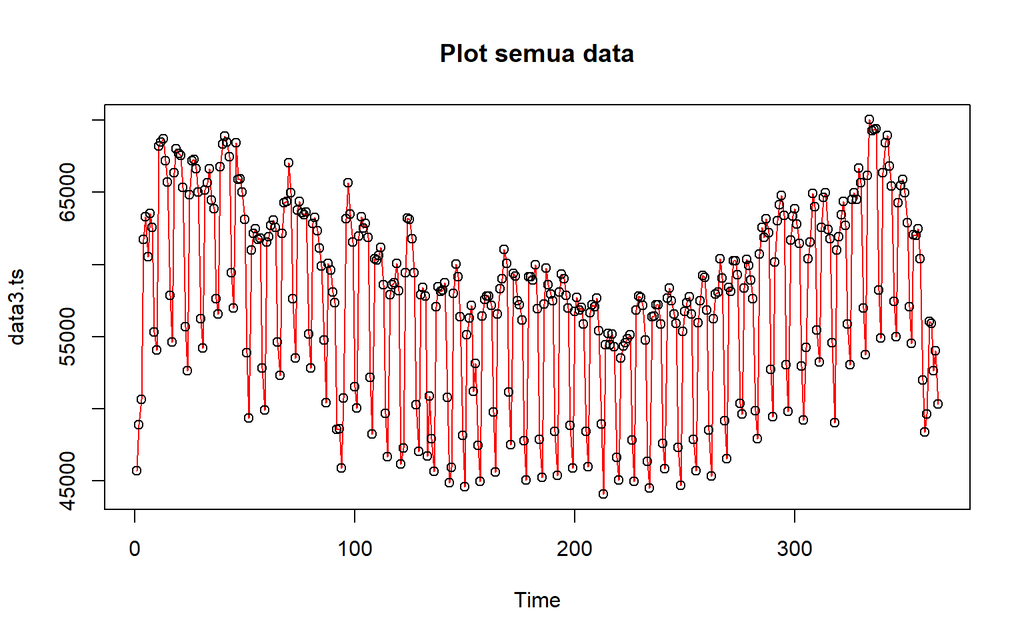

```r
#Membuat plot time series
plot(data3.ts, col="red",main="Plot semua data")
points(data3.ts)
```

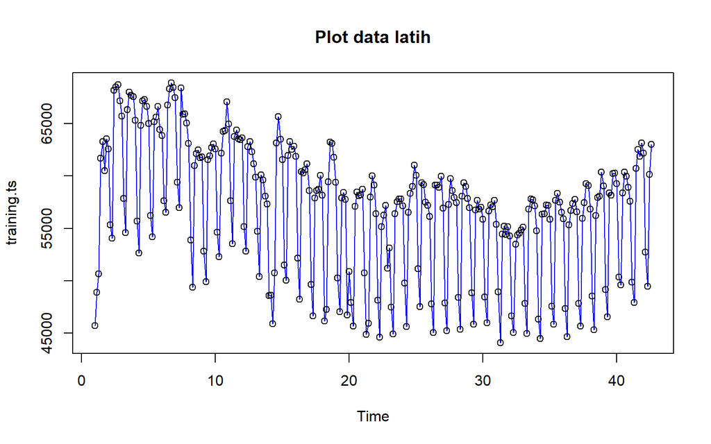

```r
plot(training.ts, col="blue",main="Plot data latih")
points(training.ts)
```

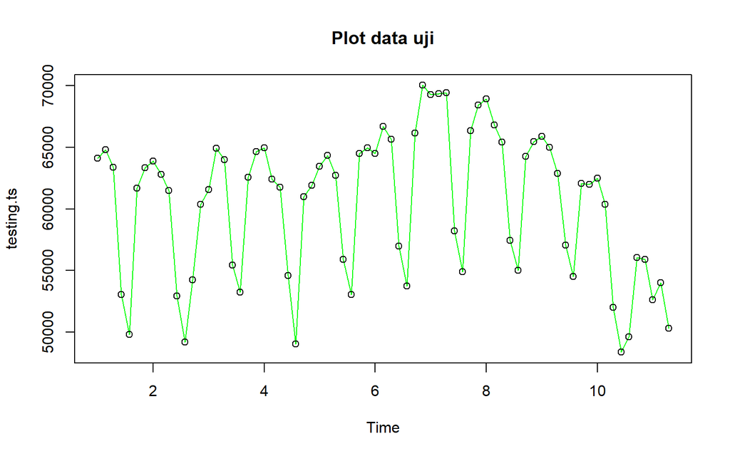

```r
plot(testing.ts, col="green",main="Plot data uji")
points(testing.ts)
```

Metode Holt-Winter untuk peramalan data musiman menggunakan tiga persamaan pemulusan yang terdiri atas persamaan untuk level $(L_t)$, trend $(B_t)$, dan komponen seasonal / musiman $(S_t)$ dengan parameter pemulusan berupa $\alpha$, $\beta$, dan $\gamma$. Metode Holt-Winter musiman terbagi menjadi dua, yaitu metode aditif dan metode multiplikatif.

Pemulusan data musiman dengan metode Winter dilakukan menggunakan fungsi `HoltWinters()` dengan memasukkan argumen tambahan, yaitu `gamma()` dan `seasonal()` . Arguman `seasonal()` diinisialisasi menyesuaikan jenis musiman, aditif atau multiplikatif.

### Winter Aditif

Perhitungan dengan model aditif dilakukan jika plot data asli menunjukkan fluktuasi musiman yang relatif stabil (konstan).

#### Pemulusan

```r
#Pemulusan dengan winter aditif
winter1 <- HoltWinters(training.ts,alpha=0.2,beta=0.1,gamma=0.1,seasonal = "additive")
winter1$fitted
```

```
## Time Series:
## Start = c(2, 1)
## End = c(42, 5)
## Frequency = 7
##               xhat    level        trend     season
##  2.000000 58757.16 56307.42  937.9827891  1511.7516
##  2.142857 52546.50 58007.48 1014.1900160 -6475.1698
##  2.285714 51722.63 59576.85 1069.7084257 -8923.9355
##  2.428571 67274.04 61111.36 1116.1886993  5046.4831
##  2.571429 68107.62 62410.11 1134.4443727  4563.0645
##  2.714286 65639.75 63619.59 1141.9477955   878.2102
##  2.857143 69983.98 65380.54 1203.8480635  3399.5959
##  3.000000 68985.20 66021.10 1147.5194023  1816.5805
##  3.142857 61340.33 66511.61 1081.8183929 -6253.0962
##  3.285714 59167.32 66893.51 1011.8263514 -8738.0144
##  3.428571 73031.21 66991.28  920.4211564  5119.5058
##  3.571429 71955.20 66575.34  786.7849739  4593.0782
##  3.714286 68410.20 66576.20  708.1918798  1125.8113
##  3.857143 71009.12 67140.99  693.8519051  3174.2813
##  4.000000 69324.68 67145.94  624.9618873  1553.7765
##  4.142857 60983.76 66971.77  545.0489307 -6533.0643
##  4.285714 57789.87 66454.67  438.8336033 -9103.6352
##  4.428571 70786.32 65865.34  336.0176868  4584.9610
##  4.571429 69507.89 65012.10  217.0914754  4278.7058
##  4.714286 66000.91 64762.08  170.3801812  1068.4514
##  4.857143 68285.60 65190.68  196.2022308  2898.7212
##  5.000000 66454.16 65056.84  163.1982293  1234.1247
##  5.142857 58107.17 64930.82  134.2765941 -6957.9256
##  5.285714 55274.29 64692.20   96.9869602 -9514.8989
##  5.428571 68755.83 64571.37   75.2053785  4109.2562
##  5.571429 68026.75 63931.22    3.6697047  4091.8606
##  5.714286 64587.33 63459.46  -43.8733174  1171.7396
##  5.857143 66590.79 63826.83   -2.7490477  2766.7052
##  6.000000 64468.94 63396.05  -45.5521633  1118.4381
##  6.142857 56065.23 63229.93  -57.6092714 -7107.0842
##  6.285714 53855.59 63484.05  -26.4359264 -9602.0252
##  6.428571 67844.76 63994.40   27.2426886  3823.1135
##  6.571429 67713.03 63805.69    5.6477534  3901.6885
##  6.714286 65290.39 63936.04   18.1175490  1336.2367
##  6.857143 67356.85 64671.50   89.8518722  2595.4927
```

[output cut: 235 more lines]

```
## 40.571429 60600.55 57477.28  142.0839588  2981.1880
## 40.714286 60866.27 57573.53  137.5006980  3155.2338
## 40.857143 60689.54 57528.94  119.2911586  3041.3089
## 41.000000 59097.06 57297.82   84.2500036  1714.9907
## 41.142857 50556.24 57084.72   54.5154434 -6582.9947
## 41.285714 47870.12 57000.12   40.6039941 -9170.6103
## 41.428571 58766.70 57048.08   41.3388660  1677.2883
## 41.571429 60524.51 57481.14   80.5118140  2962.8550
## 41.714286 61171.67 57968.12  121.1582034  3082.3957
## 41.857143 61262.60 58226.56  134.8869365  2901.1442
## 42.000000 60511.38 58742.35  172.9764131  1596.0524
## 42.142857 52820.36 59252.33  206.6769024 -6638.6405
## 42.285714 50481.68 59444.16  205.1924147 -9167.6708
## 42.428571 61461.43 59442.90  184.5473816  1833.9801
## 42.571429 62649.56 59365.74  158.3765894  3125.4405
```

```r
xhat1 <- winter1$fitted[,2]

winter1.opt<- HoltWinters(training.ts, alpha= NULL,  beta = NULL, gamma = NULL, seasonal = "additive")
winter1.opt
```

```
## Holt-Winters exponential smoothing with trend and additive seasonal component.
##
## Call:
## HoltWinters(x = training.ts, alpha = NULL, beta = NULL, gamma = NULL,     seasonal = "additive")
##
## Smoothing parameters:
##  alpha: 0.6390648
##  beta : 0.03418694
##  gamma: 0.3467223
##
## Coefficients:
##          [,1]
## a  59813.7872
## b    106.2155
## s1  2840.9207
## s2  2974.7702
## s3  1531.1506
## s4 -7063.5051
## s5 -9409.3766
## s6  1502.1918
## s7  2859.4544
```

```r
winter1.opt$fitted
```

```
## Time Series:
## Start = c(2, 1)
## End = c(42, 5)
## Frequency = 7
##               xhat    level        trend     season
##  2.000000 58757.16 56307.42  937.9827891  1511.7516
##  2.142857 54226.54 59680.47 1021.2303067 -6475.1698
##  2.285714 53523.28 61402.05 1045.1728305 -8923.9355
##  2.428571 68884.77 62781.68 1056.6069432  5046.4831
##  2.571429 68996.67 63392.25 1041.3584083  4563.0645
##  2.714286 66013.55 64105.20 1030.1312452   878.2102
##  2.857143 71363.55 66874.37 1089.5834378  3399.5959
##  3.000000 68268.94 65282.44  997.9106753  1988.5965
##  3.142857 59242.48 64638.72  941.7885071 -6338.0261
##  3.285714 56737.42 64684.70  911.1634469 -8858.4405
##  3.428571 70051.57 64228.03  864.4015365  4959.1389
##  3.571429 68008.78 62726.51  783.5176901  4498.7549
##  3.714286 65523.38 63520.74  783.8841194  1218.7546
##  3.857143 69397.06 65691.28  831.2896270  2874.4910
##  4.000000 67809.90 65351.52  791.2550442  1667.1266
##  4.142857 58780.94 64557.34  737.0537408 -6513.4476
##  4.285714 54851.07 63308.21  669.1521882 -9126.2944
##  4.428571 67687.02 62570.14  621.0437224  4495.8332
##  4.571429 66431.46 61371.76  558.8432106  4500.8538
##  4.714286 64469.39 62404.07  575.0295065  1490.2950
##  4.857143 68064.80 64782.93  636.6970787  2645.1714
##  5.000000 66468.28 64506.15  605.4679705  1356.6596
##  5.142857 57849.63 64178.46  573.5660533 -6902.3902
##  5.285714 54861.68 63725.08  538.4580934 -9401.8615
##  5.428571 68494.46 63831.23  523.6788211  4139.5464
##  5.571429 67280.97 62236.15  451.2448765  4593.5695
##  5.714286 63903.98 61644.85  415.6033437  1843.5292
##  5.857143 66752.95 63811.21  475.4563435  2466.2899
##  6.000000 64414.41 62815.33  425.1559373  1173.9242
##  6.142857 56199.75 62890.07  413.1762089 -7103.4899
##  6.285714 55171.14 64213.37  444.2904894 -9486.5177
##  6.428571 69730.97 65532.14  474.1864447  3724.6421
##  6.571429 68909.69 64110.89  409.3871479  4389.4135
##  6.714286 66737.22 64153.98  396.8647737  2186.3694
##  6.857143 68540.16 65918.38  443.6164512  2178.1673
```

[output cut: 235 more lines]

```
## 40.571429 60034.18 57500.62   68.3772606  2465.1809
## 40.714286 60915.18 57784.50   75.7444818  3054.9395
## 40.857143 60322.72 57247.13   54.7839882  3020.8098
## 41.000000 57928.85 56416.65   24.5196582  1487.6796
## 41.142857 49233.88 56237.62   17.5606872 -7021.2974
## 41.285714 47400.48 56655.74   31.2545977 -9286.5142
## 41.428571 58350.99 57010.60   42.3178851  1298.0693
## 41.571429 61171.86 58570.29   94.1921180  2507.3806
## 41.714286 62608.89 59549.57  124.4504123  2934.8770
## 41.857143 62149.72 59194.22  108.0475395  2847.4546
## 42.000000 61530.51 59952.42  130.2742795  1447.8184
## 42.142857 53710.20 60508.24  144.8224152 -6942.8582
## 42.285714 50937.58 60036.96  123.7598874 -9223.1433
## 42.428571 60896.15 59209.70   91.2473000  1595.2069
## 42.571429 61581.66 58825.95   75.0087402  2680.7012
```

```r
xhat1.opt <- winter1.opt$fitted[,2]
```

#### Peramalan

```r
#Forecast
h_seasonal <- length(testing.ts)
forecast1 <- predict(winter1, n.ahead = h_seasonal)
forecast1.opt <- predict(winter1.opt, n.ahead = h_seasonal)
```

#### Plot Deret Waktu

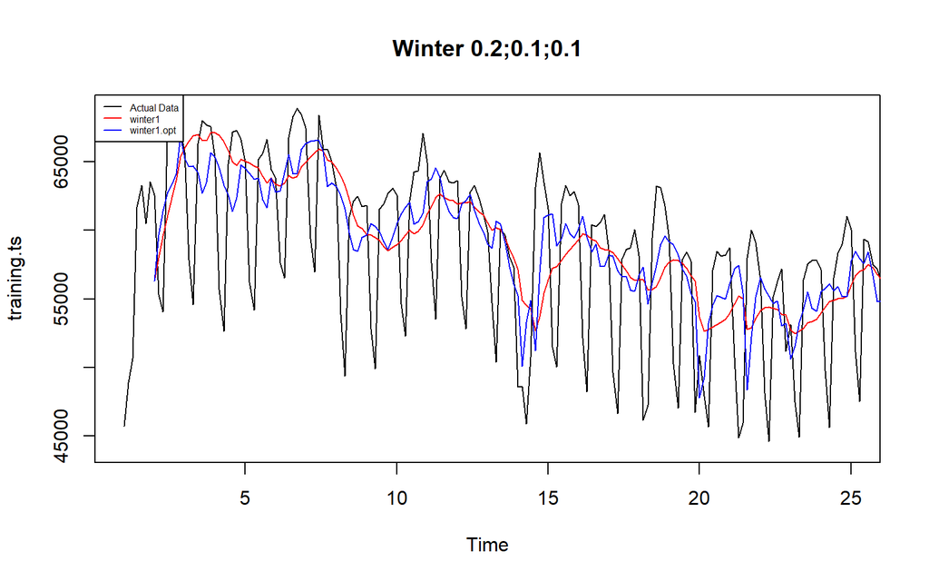

```r
#Plot time series
plot(training.ts,main="Winter 0.2;0.1;0.1",type="l",col="black",
     xlim=c(1,25),pch=12)
lines(xhat1,type="l",col="red")
lines(xhat1.opt,type="l",col="blue")
lines(forecast1,type="l",col="red")
lines(forecast1.opt,type="l",col="blue")
legend("topleft",c("Actual Data",expression(paste(winter1)),
                   expression(paste(winter1.opt))),cex=0.5,
       col=c("black","red","blue"),lty=1)
```

#### Akurasi Data Latih

```r
#Akurasi data training
SSE1<-winter1$SSE
MSE1<-winter1$SSE/length(training.ts)
RMSE1<-sqrt(MSE1)
akurasi1 <- matrix(c(SSE1,MSE1,RMSE1))
row.names(akurasi1)<- c("SSE", "MSE", "RMSE")
colnames(akurasi1) <- c("Akurasi")
akurasi1
```

```
##           Akurasi
## SSE  1.687725e+09
## MSE  5.779881e+06
## RMSE 2.404138e+03
```

```r
SSE1.opt<-winter1.opt$SSE
MSE1.opt<-winter1.opt$SSE/length(training.ts)
RMSE1.opt<-sqrt(MSE1.opt)
akurasi1.opt <- matrix(c(SSE1.opt,MSE1.opt,RMSE1.opt))
row.names(akurasi1.opt)<- c("SSE1.opt", "MSE1.opt", "RMSE1.opt")
colnames(akurasi1.opt) <- c("Akurasi")
akurasi1.opt
```

```
##                Akurasi
## SSE1.opt  1.254229e+09
## MSE1.opt  4.295306e+06
## RMSE1.opt 2.072512e+03
```

```r
akurasi1.train = data.frame(Model_Winter = c("Winter 1","Winter1 optimal"),
                            Nilai_SSE=c(SSE1,SSE1.opt),
                            Nilai_MSE=c(MSE1,MSE1.opt),Nilai_RMSE=c(RMSE1,RMSE1.opt))
akurasi1.train
```

```
##      Model_Winter  Nilai_SSE Nilai_MSE Nilai_RMSE
## 1        Winter 1 1687725286   5779881   2404.138
## 2 Winter1 optimal 1254229285   4295306   2072.512
```

#### Akurasi Data Uji

```r
#Akurasi Data Testing
forecast1<-data.frame(forecast1)
testing.ts<-data.frame(testing.ts)
selisih1<-forecast1-testing.ts
SSEtesting1<-sum(selisih1^2)
MSEtesting1<-SSEtesting1/nrow(testing.ts)

forecast1.opt<-data.frame(forecast1.opt)
selisih1.opt<-forecast1.opt-testing.ts
SSEtesting1.opt<-sum(selisih1.opt^2)
MSEtesting1.opt<-SSEtesting1.opt/nrow(testing.ts)
```

```r
akurasi_testing <- data.frame(
  Model = c("Model1", "Model Optimum"),
  SSE   = c(SSEtesting1, SSEtesting1.opt),
  MSE   = c(MSEtesting1, MSEtesting1.opt)
)

akurasi_testing
```

```
##           Model        SSE      MSE
## 1        Model1 4171987227 57150510
## 2 Model Optimum 2275348091 31169152
```

### Winter Multiplikatif

Model multiplikatif digunakan cocok digunakan jika plot data asli menunjukkan fluktuasi musiman yang bervariasi.

#### Pemulusan

```r
#Pemulusan dengan winter multiplikatif
winter2 <- HoltWinters(training.ts,alpha=0.2,beta=0.1,gamma=0.3,seasonal = "multiplicative")
winter2$fitted
```

```
## Time Series:
## Start = c(2, 1)
## End = c(42, 5)
## Frequency = 7
##               xhat    level        trend    season
##  2.000000 58561.54 56307.42  937.9827891 1.0229911
##  2.142857 52767.02 58028.60 1016.3017579 0.8936762
##  2.285714 51999.86 59616.78 1073.4902761 0.8568071
##  2.428571 67460.41 61168.04 1121.2672880 1.0830175
##  2.571429 68377.84 62423.46 1134.6818054 1.0758314
##  2.714286 65553.47 63577.65 1136.6328926 1.0129676
##  2.857143 70182.29 65342.39 1199.4441052 1.0547092
##  3.000000 69767.37 65970.17 1142.2768653 1.0395594
##  3.142857 60921.70 66329.95 1064.0279758 0.9039635
##  3.285714 58556.60 66712.32  995.8621972 0.8648379
##  3.428571 73505.89 66792.51  904.2948938 1.0858103
##  3.571429 72269.86 66378.62  772.4764514 1.0762275
##  3.714286 68709.05 66362.36  693.6025507 1.0246524
##  3.857143 70485.39 66857.68  673.7743094 1.0437416
##  4.000000 69268.72 66971.78  617.8070498 1.0248430
##  4.142857 60145.86 66820.75  540.9232457 0.8928796
##  4.285714 56821.21 66359.78  440.7333664 0.8506104
##  4.428571 70127.61 65819.54  342.6358934 1.0599351
##  4.571429 69389.18 65164.45  242.8637652 1.0608779
##  4.714286 66559.83 64989.39  201.0710899 1.0210058
##  4.857143 67730.43 65333.88  215.4133644 1.0332747
##  5.000000 66232.28 65337.34  194.2180724 1.0106929
##  5.142857 57388.35 65289.31  169.9931225 0.8767028
##  5.285714 54586.37 65197.95  143.8574208 0.8353974
##  5.428571 68025.35 65245.76  134.2533608 1.0404610
##  5.571429 68332.76 64832.89   79.5410010 1.0526913
##  5.714286 65957.95 64402.66   28.5639358 1.0236954
##  5.857143 66497.04 64565.17   41.9583889 1.0292524
##  6.000000 64609.32 64209.48    2.1933388 1.0061928
##  6.142857 55883.88 64063.94  -12.5799877 0.8724855
##  6.285714 53769.21 64450.22   27.3065078 0.8339217
##  6.428571 67187.82 65141.93   93.7469287 1.0299244
##  6.571429 68024.33 65153.58   85.5363709 1.0426924
##  6.714286 67106.62 65298.99   91.5245779 1.0262438
##  6.857143 67284.43 65735.56  126.0289159 1.0216034
```

[output cut: 235 more lines]

```
## 40.571429 60449.75 58360.14  155.9278957 1.0330454
## 40.714286 61424.26 58500.89  154.4108333 1.0472072
## 40.857143 61511.05 58374.85  126.3653833 1.0514491
## 41.000000 59536.81 58011.69   77.4125569 1.0249222
## 41.142857 50079.13 57713.17   39.8198928 0.8671262
## 41.285714 47769.98 57702.61   34.7810823 0.8273666
## 41.428571 58531.37 57770.47   38.0898070 1.0125034
## 41.571429 60231.94 58241.94   81.4276013 1.0327239
## 41.714286 61324.97 58773.61  126.4520855 1.0411698
## 41.857143 61552.17 59002.48  136.6932273 1.0408020
## 42.000000 60625.40 59449.49  167.7251471 1.0169109
## 42.142857 52081.17 59926.19  198.6226794 0.8662176
## 42.285714 50083.72 60278.35  213.9761265 0.8279352
## 42.428571 61841.99 60339.10  198.6538032 1.0215442
## 42.571429 62921.43 60207.06  165.5841901 1.0422175
```

```r
xhat2 <- winter2$fitted[,2]

winter2.opt<- HoltWinters(training.ts, alpha= NULL,  beta = NULL, gamma = NULL, seasonal = "multiplicative")
winter2.opt$fitted
```

```
## Time Series:
## Start = c(2, 1)
## End = c(42, 5)
## Frequency = 7
##               xhat    level        trend    season
##  2.000000 58561.54 56307.42  937.9827891 1.0229911
##  2.142857 54362.11 59801.74 1028.0240791 0.8936762
##  2.285714 53622.39 61531.23 1052.7320672 0.8568071
##  2.428571 69282.06 62907.21 1064.1174682 1.0830175
##  2.571429 69231.92 63311.16 1040.8644894 1.0758314
##  2.714286 65764.20 63897.46 1024.8534815 1.0129676
##  2.857143 71645.29 66836.67 1092.2825791 1.0547092
##  3.000000 68217.20 65157.51  994.6643910 1.0312164
##  3.142857 58658.91 64558.78  938.5405450 0.8955925
##  3.285714 56448.24 64900.95  917.5345143 0.8576352
##  3.428571 70557.83 64409.43  867.9036387 1.0808933
##  3.571429 68238.98 62735.67  778.3790546 1.0743918
##  3.714286 65340.30 63384.38  773.8114096 1.0184250
##  3.857143 69570.01 65666.37  826.9339718 1.0462710
##  4.000000 67769.92 65242.08  782.8622391 1.0264290
##  4.142857 58292.37 64472.56  728.1828595 0.8940446
##  4.285714 54619.22 63288.16  660.8163235 0.8541061
##  4.428571 67632.02 62443.18  607.7778076 1.0726564
##  4.571429 66478.96 61351.80  547.9282640 1.0739783
##  4.714286 64319.25 62321.18  562.7729936 1.0228246
##  4.857143 68190.61 64781.26  629.6016905 1.0424967
##  5.000000 66448.73 64437.01  595.2997951 1.0217803
##  5.142857 57493.46 64111.90  562.8802830 0.8889626
##  5.285714 54658.71 63756.29  530.5285499 0.8502320
##  5.428571 68762.95 63923.27  517.7232745 1.0670685
##  5.571429 67412.23 62248.47  440.4963286 1.0753444
##  5.714286 63786.85 61618.94  402.8069368 1.0284593
##  5.857143 66843.72 63834.99  466.6746444 1.0395332
##  6.000000 64414.99 62798.87  413.7418166 1.0190212
##  6.142857 56085.45 62860.97  401.3560086 0.8865537
##  6.285714 55067.01 64395.14  441.2568477 0.8493225
##  6.428571 70436.20 65968.19  481.1217695 1.0599991
##  6.571429 69229.52 64188.41  401.4863025 1.0718320
##  6.714286 66615.96 64046.01  382.3292965 1.0339543
##  6.857143 68598.99 65855.95  432.6136427 1.0348541
```

[output cut: 235 more lines]

```
## 40.571429 60439.65 57618.87   75.3490564 1.0475859
## 40.714286 61085.06 57651.68   73.8508265 1.0581982
## 40.857143 60285.27 57028.89   49.3130660 1.0561872
## 41.000000 57783.13 56245.17   19.9713354 1.0269791
## 41.142857 49040.21 56155.31   16.1024969 0.8730457
## 41.285714 47255.38 56784.89   37.7110644 0.8316300
## 41.428571 58740.22 57333.99   55.7236264 1.0235322
## 41.571429 61543.55 58655.81  100.3193046 1.0474405
## 41.714286 62828.90 59387.64  122.5628449 1.0557668
## 41.857143 62153.42 58909.95  101.4201353 1.0532448
## 42.000000 61352.95 59639.63  123.5492486 1.0266012
## 42.142857 52875.82 60299.51  142.4405534 0.8748198
## 42.285714 50384.88 60345.18  139.0321063 0.8330252
## 42.428571 61521.88 59751.15  113.2114797 1.0276878
## 42.571429 62003.78 58994.77   82.5817691 1.0495355
```

```r
xhat2.opt <- winter2.opt$fitted[,2]
```

#### Peramalan

```r
#Forecast
forecast2 <- predict(winter2, n.ahead = h_seasonal)
forecast2.opt <- predict(winter2.opt, n.ahead = h_seasonal)
```

#### Plot Deret Waktu

[figure not shown]

```r
#Plot time series
plot(training.ts,main="Winter 0.2;0.1;0.1",type="l",col="black",
     xlim=c(1,25),pch=12)
lines(xhat2,type="l",col="red")
lines(xhat2.opt,type="l",col="blue")
lines(forecast2,type="l",col="red")
lines(forecast2.opt,type="l",col="blue")
legend("topleft",c("Actual Data",expression(paste(winter2)),
                   expression(paste(winter2.opt))),cex=0.5,
       col=c("black","red","blue"),lty=1)
```

#### Akurasi Data Latih

```r
#Akurasi data training
SSE2<-winter2$SSE
MSE2<-winter2$SSE/length(training.ts)
RMSE2<-sqrt(MSE2)
akurasi1 <- matrix(c(SSE2,MSE2,RMSE2))
row.names(akurasi1)<- c("SSE2", "MSE2", "RMSE2")
colnames(akurasi1) <- c("Akurasi lamda=0.2")
akurasi1
```

```
##       Akurasi lamda=0.2
## SSE2       1.725188e+09
## MSE2       5.908179e+06
## RMSE2      2.430675e+03
```

```r
SSE2.opt<-winter2.opt$SSE
MSE2.opt<-winter2.opt$SSE/length(training.ts)
RMSE2.opt<-sqrt(MSE2.opt)
akurasi1.opt <- matrix(c(SSE2.opt,MSE2.opt,RMSE2.opt))
row.names(akurasi1.opt)<- c("SSE2.opt", "MSE2.opt", "RMSE2.opt")
colnames(akurasi1.opt) <- c("Akurasi")
akurasi1.opt
```

```
##                Akurasi
## SSE2.opt  1.249610e+09
## MSE2.opt  4.279486e+06
## RMSE2.opt 2.068692e+03
```

```r
akurasi2.train = data.frame(Model_Winter = c("Winter 1","winter2 optimal"),
                            Nilai_SSE=c(SSE2,SSE2.opt),
                            Nilai_MSE=c(MSE2,MSE2.opt),Nilai_RMSE=c(RMSE2,RMSE2.opt))
akurasi2.train
```

```
##      Model_Winter  Nilai_SSE Nilai_MSE Nilai_RMSE
## 1        Winter 1 1725188324   5908179   2430.675
## 2 winter2 optimal 1249609929   4279486   2068.692
```

#### Akurasi Data Uji

```r
#Akurasi Data Testing
forecast2<-data.frame(forecast2)
testing.ts<-data.frame(testing.ts)
selisih2<-forecast2-testing.ts
SSEtesting2<-sum(selisih2^2)
MSEtesting2<-SSEtesting2/nrow(testing.ts)

forecast2.opt<-data.frame(forecast2.opt)
selisih2.opt<-forecast2.opt-testing.ts
SSEtesting2.opt<-sum(selisih2.opt^2)
MSEtesting2.opt<-SSEtesting2.opt/nrow(testing.ts)
```

```r
# Atau rapikan dalam tabel
akurasi_testing2 <- data.frame(
  Model = c("Model2", "Model2 Optimal"),
  SSE   = c(SSEtesting2, SSEtesting2.opt),
  MSE   = c(MSEtesting2, MSEtesting2.opt)
)

akurasi_testing2
```

```
##            Model        SSE      MSE
## 1         Model2 4378127351 59974347
## 2 Model2 Optimal 2289970698 31369462
```